# Chicago Micro-mobility Analysis (Divvy)

39 rows × 39 columns

Because the siz of the matrix is too large, it is hard to conclude here, so we will wait untile the next part for further analysis.

```python
age_group_31_40_2017 = df_MM_clean_2017[df_MM_clean_2017['age group'] == '31-40']
# OD Matrix 2018 calculation using pivot table
matrix_age_31_40_2017 = (
    age_group_31_40_2017.assign(count=1)
    .pivot_table(index='FROM WARD', columns='TO WARD',
                 values="count", aggfunc="count")
    .fillna(0)
    .astype(int)
).sort_values('FROM WARD')

matrix_age_31_40_2017
```

| TO WARD FROM WARD | 1.0 | 2.0 | 3.0 | 4.0 | 5.0 | 6.0 | 7.0 | 8.0 | 11.0 | 12.0 | ... | 40.0 | 42.0 | 43.0 | 44.0 | 45.0 | 46.0 | 47.0 | 48.0 | 49.0 | 50.0 |
| --- | --- | --- | --- | --- | --- | --- | --- | --- | --- | --- | --- | --- | --- | --- | --- | --- | --- | --- | --- | --- | --- |
| 1.0 | 15564 | 1728 | 28 | 223 | 0 | 0 | 0 | 0 | 14 | 1 | ... | 17 | 7293 | 2023 | 580 | 58 | 114 | 639 | 21 | 90 | 0 |
| 2.0 | 1940 | 12849 | 802 | 1382 | 7 | 0 | 0 | 0 | 49 | 2 | ... | 10 | 24487 | 12291 | 2652 | 1 | 1438 | 296 | 118 | 9 | 0 |
| 3.0 | 21 | 719 | 2382 | 3234 | 429 | 0 | 0 | 0 | 720 | 17 | ... | 0 | 3983 | 72 | 8 | 0 | 2 | 0 | 0 | 0 | 0 |
| 4.0 | 225 | 1605 | 3741 | 8920 | 3663 | 0 | 1 | 0 | 1073 | 1 | ... | 2 | 9837 | 484 | 56 | 1 | 23 | 22 | 8 | 0 | 0 |
| 5.0 | 2 | 6 | 378 | 3599 | 9537 | 5 | 19 | 74 | 17 | 1 | ... | 0 | 51 | 6 | 2 | 0 | 3 | 0 | 1 | 0 | 0 |
| 6.0 | 0 | 0 | 1 | 0 | 1 | 250 | 0 | 39 | 1 | 0 | ... | 0 | 0 | 0 | 0 | 0 | 0 | 0 | 0 | 0 | 0 |
| 7.0 | 0 | 0 | 0 | 2 | 19 | 0 | 45 | 9 | 0 | 0 | ... | 0 | 0 | 0 | 0 | 0 | 0 | 0 | 0 | 0 | 0 |
| 8.0 | 0 | 0 | 0 | 0 | 75 | 45 | 1 | 73 | 0 | 0 | ... | 0 | 0 | 0 | 0 | 0 | 0 | 0 | 0 | 0 | 0 |
| 11.0 | 17 | 16 | 590 | 932 | 18 | 2 | 0 | 0 | 3712 | 124 | ... | 0 | 687 | 16 | 0 | 0 | 0 | 0 | 0 | 0 | 0 |
| 12.0 | 0 | 0 | 12 | 0 | 0 | 0 | 0 | 0 | 139 | 48 | ... | 0 | 1 | 0 | 0 | 0 | 0 | 0 | 0 | 0 | 0 |
| 15.0 | 0 | 0 | 0 | 1 | 2 | 0 | 0 | 0 | 19 | 24 | ... | 0 | 0 | 0 | 0 | 0 | 0 | 0 | 0 | 0 | 0 |
| 16.0 | 0 | 0 | 0 | 1 | 0 | 4 | 0 | 0 | 1 | 2 | ... | 0 | 0 | 0 | 0 | 0 | 0 | 0 | 0 | 0 | 0 |
| 17.0 | 0 | 0 | 0 | 0 | 0 | 0 | 0 | 0 | 0 | 0 | ... | 0 | 0 | 0 | 0 | 0 | 0 | 0 | 0 | 0 | 0 |
| 20.0 | 0 | 0 | 386 | 82 | 275 | 10 | 0 | 2 | 5 | 1 | ... | 0 | 1 | 1 | 0 | 0 | 0 | 0 | 0 | 0 | 0 |
| 22.0 | 0 | 0 | 0 | 0 | 0 | 0 | 0 | 0 | 0 | 2 | ... | 0 | 0 | 0 | 0 | 0 | 0 | 0 | 0 | 0 | 0 |
| 24.0 | 2 | 0 | 0 | 0 | 0 | 0 | 0 | 0 | 0 | 4 | ... | 0 | 2 | 2 | 0 | 0 | 0 | 0 | 0 | 0 | 0 |
| 25.0 | 191 | 123 | 469 | 456 | 5 | 0 | 0 | 0 | 591 | 136 | ... | 0 | 1699 | 36 | 22 | 0 | 0 | 2 | 0 | 0 | 0 |
| 26.0 | 2516 | 160 | 2 | 4 | 0 | 0 | 0 | 0 | 3 | 2 | ... | 6 | 294 | 148 | 14 | 0 | 3 | 131 | 0 | 0 | 0 |
| 27.0 | 6430 | 8281 | 171 | 618 | 3 | 0 | 0 | 0 | 121 | 13 | ... | 8 | 24559 | 5864 | 1645 | 2 | 414 | 493 | 18 | 6 | 0 |
| 28.0 | 246 | 277 | 560 | 1138 | 1 | 0 | 0 | 0 | 407 | 9 | ... | 0 | 3260 | 58 | 90 | 0 | 7 | 4 | 0 | 0 | 0 |
| 29.0 | 0 | 0 | 0 | 0 | 0 | 0 | 0 | 0 | 0 | 0 | ... | 0 | 1 | 0 | 0 | 0 | 0 | 0 | 0 | 0 | 0 |
| 30.0 | 102 | 1 | 0 | 0 | 0 | 0 | 0 | 0 | 0 | 0 | ... | 2 | 2 | 2 | 17 | 203 | 2 | 29 | 1 | 0 | 0 |
| 32.0 | 7606 | 1544 | 3 | 109 | 0 | 0 | 0 | 0 | 2 | 0 | ... | 145 | 2846 | 7338 | 4858 | 67 | 853 | 3846 | 75 | 8 | 1 |
| 33.0 | 218 | 8 | 0 | 2 | 0 | 0 | 0 | 0 | 0 | 0 | ... | 310 | 4 | 105 | 153 | 128 | 235 | 950 | 37 | 4 | 3 |
| 34.0 | 4205 | 9417 | 6059 | 7659 | 13 | 0 | 0 | 0 | 894 | 28 | ... | 5 | 45858 | 3456 | 810 | 0 | 102 | 83 | 12 | 7 | 0 |
| 35.0 | 2366 | 74 | 0 | 5 | 0 | 0 | 0 | 0 | 2 | 1 | ... | 66 | 280 | 509 | 284 | 203 | 55 | 425 | 13 | 0 | 0 |
| 36.0 | 3259 | 264 | 5 | 17 | 0 | 0 | 0 | 0 | 6 | 0 | ... | 3 | 1440 | 234 | 56 | 1 | 10 | 97 | 2 | 0 | 0 |
| 37.0 | 0 | 0 | 0 | 0 | 0 | 0 | 0 | 0 | 0 | 0 | ... | 0 | 0 | 0 | 0 | 0 | 0 | 0 | 0 | 0 | 0 |
| 39.0 | 70 | 0 | 0 | 0 | 0 | 0 | 0 | 0 | 0 | 0 | ... | 89 | 0 | 5 | 12 | 68 | 19 | 206 | 19 | 7 | 3 |
| 40.0 | 37 | 15 | 0 | 0 | 0 | 0 | 0 | 0 | 0 | 0 | ... | 1170 | 19 | 91 | 383 | 36 | 351 | 3152 | 1486 | 586 | 99 |
| 42.0 | 8392 | 28669 | 4266 | 9422 | 54 | 0 | 0 | 0 | 764 | 5 | ... | 15 | 83880 | 15447 | 3061 | 6 | 973 | 412 | 280 | 12 | 2 |
| 43.0 | 1982 | 10664 | 41 | 364 | 3 | 0 | 0 | 0 | 8 | 0 | ... | 112 | 11406 | 29066 | 8679 | 6 | 4603 | 1841 | 1225 | 59 | 2 |
| 44.0 | 519 | 2011 | 5 | 27 | 0 | 0 | 0 | 0 | 1 | 0 | ... | 324 | 1993 | 7293 | 12520 | 24 | 7453 | 3423 | 1037 | 92 | 5 |
| 45.0 | 79 | 0 | 0 | 0 | 0 | 0 | 0 | 0 | 0 | 0 | ... | 25 | 1 | 1 | 16 | 845 | 42 | 219 | 7 | 2 | 0 |
| 46.0 | 106 | 1399 | 1 | 19 | 0 | 0 | 0 | 0 | 0 | 0 | ... | 333 | 610 | 4061 | 6631 | 30 | 14801 | 4387 | 2571 | 193 | 5 |
| 47.0 | 532 | 352 | 0 | 38 | 0 | 0 | 0 | 0 | 0 | 0 | ... | 3333 | 202 | 1566 | 3181 | 234 | 4253 | 16479 | 2760 | 187 | 26 |
| 48.0 | 19 | 116 | 3 | 1 | 0 | 0 | 0 | 0 | 0 | 0 | ... | 1371 | 71 | 928 | 918 | 4 | 1911 | 2343 | 4880 | 821 | 44 |
| 49.0 | 38 | 6 | 0 | 0 | 0 | 0 | 0 | 0 | 0 | 0 | ... | 684 | 5 | 12 | 41 | 1 | 185 | 218 | 736 | 4821 | 59 |
| 50.0 | 0 | 0 | 0 | 0 | 0 | 0 | 0 | 0 | 0 | 0 | ... | 99 | 0 | 0 | 2 | 0 | 4 | 28 | 55 | 59 | 6 |

39 rows × 39 columns

```python
age_group_41_50_2017 = df_MM_clean_2017[df_MM_clean_2017['age group'] == '41-50']
# OD Matrix 2018 calculation using pivot table
matrix_age_41_50_2017 = (
    age_group_41_50_2017.assign(count=1)
    .pivot_table(index='FROM WARD', columns='TO WARD',
                 values="count", aggfunc="count")
    .fillna(0)
    .astype(int)
).sort_values('FROM WARD')

matrix_age_41_50_2017
```

| TO WARD FROM WARD | 1.0 | 2.0 | 3.0 | 4.0 | 5.0 | 6.0 | 7.0 | 8.0 | 11.0 | 12.0 | ... | 40.0 | 42.0 | 43.0 | 44.0 | 45.0 | 46.0 | 47.0 | 48.0 | 49.0 | 50.0 |
| --- | --- | --- | --- | --- | --- | --- | --- | --- | --- | --- | --- | --- | --- | --- | --- | --- | --- | --- | --- | --- | --- |
| 1.0 | 3548 | 295 | 4 | 34 | 0 | 0 | 0 | 0 | 2 | 0 | ... | 7 | 2196 | 353 | 130 | 16 | 38 | 252 | 30 | 1 | 0 |
| 2.0 | 314 | 3761 | 141 | 390 | 3 | 0 | 0 | 0 | 1 | 0 | ... | 3 | 8840 | 3798 | 775 | 0 | 524 | 110 | 30 | 3 | 0 |
| 3.0 | 11 | 72 | 950 | 1107 | 292 | 0 | 0 | 2 | 209 | 3 | ... | 0 | 1647 | 14 | 3 | 0 | 0 | 0 | 0 | 0 | 0 |
| 4.0 | 18 | 380 | 1375 | 3834 | 580 | 0 | 0 | 1 | 144 | 0 | ... | 1 | 4564 | 224 | 19 | 1 | 6 | 2 | 5 | 0 | 1 |
| 5.0 | 2 | 2 | 196 | 617 | 3625 | 0 | 16 | 26 | 18 | 0 | ... | 0 | 26 | 3 | 2 | 0 | 1 | 0 | 0 | 0 | 0 |
| 6.0 | 0 | 0 | 0 | 1 | 1 | 18 | 1 | 26 | 0 | 0 | ... | 0 | 3 | 0 | 0 | 0 | 0 | 0 | 0 | 0 | 0 |
| 7.0 | 0 | 0 | 0 | 0 | 17 | 0 | 97 | 1 | 0 | 0 | ... | 0 | 0 | 0 | 0 | 0 | 0 | 0 | 0 | 0 | 0 |
| 8.0 | 0 | 0 | 2 | 0 | 25 | 10 | 1 | 42 | 0 | 0 | ... | 0 | 1 | 0 | 0 | 0 | 0 | 0 | 0 | 0 | 0 |
| 11.0 | 2 | 8 | 172 | 304 | 4 | 0 | 0 | 0 | 863 | 61 | ... | 0 | 134 | 4 | 2 | 0 | 0 | 0 | 0 | 0 | 0 |
| 12.0 | 1 | 0 | 4 | 2 | 0 | 0 | 0 | 0 | 38 | 32 | ... | 0 | 0 | 0 | 0 | 0 | 0 | 0 | 0 | 0 | 0 |
| 15.0 | 1 | 0 | 3 | 15 | 0 | 0 | 0 | 0 | 149 | 9 | ... | 0 | 0 | 0 | 0 | 0 | 0 | 0 | 0 | 0 | 0 |
| 16.0 | 0 | 0 | 0 | 0 | 0 | 1 | 0 | 0 | 7 | 0 | ... | 0 | 0 | 0 | 0 | 0 | 0 | 0 | 0 | 0 | 0 |
| 17.0 | 0 | 0 | 0 | 0 | 0 | 0 | 0 | 0 | 0 | 0 | ... | 0 | 0 | 0 | 0 | 0 | 0 | 0 | 0 | 0 | 0 |
| 20.0 | 0 | 0 | 47 | 28 | 144 | 5 | 0 | 8 | 10 | 6 | ... | 0 | 1 | 0 | 0 | 0 | 0 | 0 | 0 | 0 | 0 |
| 22.0 | 0 | 0 | 0 | 4 | 0 | 0 | 0 | 0 | 0 | 1 | ... | 0 | 1 | 0 | 0 | 0 | 0 | 0 | 0 | 0 | 0 |
| 24.0 | 0 | 0 | 1 | 0 | 0 | 0 | 0 | 0 | 1 | 0 | ... | 0 | 2 | 0 | 0 | 0 | 0 | 0 | 0 | 0 | 0 |
| 25.0 | 45 | 25 | 158 | 144 | 2 | 0 | 0 | 0 | 225 | 31 | ... | 0 | 446 | 20 | 2 | 0 | 0 | 0 | 1 | 0 | 0 |
| 26.0 | 656 | 14 | 0 | 2 | 0 | 0 | 0 | 0 | 0 | 0 | ... | 1 | 212 | 54 | 4 | 3 | 2 | 17 | 1 | 0 | 0 |
| 27.0 | 1448 | 2341 | 91 | 407 | 0 | 0 | 0 | 0 | 26 | 109 | ... | 2 | 11144 | 1491 | 333 | 1 | 79 | 31 | 6 | 0 | 1 |
| 28.0 | 57 | 68 | 140 | 421 | 1 | 0 | 0 | 0 | 123 | 12 | ... | 0 | 1365 | 15 | 3 | 0 | 0 | 2 | 0 | 0 | 0 |
| 29.0 | 0 | 0 | 0 | 0 | 0 | 0 | 0 | 0 | 0 | 0 | ... | 0 | 0 | 0 | 0 | 0 | 0 | 0 | 0 | 0 | 0 |
| 30.0 | 48 | 0 | 0 | 0 | 0 | 0 | 0 | 0 | 0 | 0 | ... | 1 | 0 | 2 | 2 | 16 | 0 | 21 | 0 | 0 | 1 |
| 32.0 | 1854 | 464 | 0 | 42 | 0 | 0 | 0 | 0 | 0 | 0 | ... | 32 | 1043 | 3360 | 1630 | 13 | 343 | 1555 | 51 | 3 | 0 |
| 33.0 | 38 | 0 | 0 | 0 | 0 | 0 | 0 | 0 | 0 | 0 | ... | 51 | 0 | 20 | 15 | 26 | 40 | 241 | 25 | 1 | 1 |
| 34.0 | 1169 | 4303 | 2358 | 4678 | 5 | 0 | 0 | 0 | 179 | 70 | ... | 0 | 26390 | 1742 | 259 | 10 | 42 | 31 | 2 | 3 | 0 |
| 35.0 | 603 | 3 | 0 | 0 | 0 | 0 | 0 | 0 | 0 | 0 | ... | 30 | 11 | 60 | 36 | 50 | 11 | 193 | 12 | 3 | 1 |
| 36.0 | 1179 | 176 | 9 | 15 | 0 | 0 | 0 | 0 | 0 | 0 | ... | 1 | 434 | 31 | 27 | 1 | 6 | 7 | 6 | 0 | 0 |
| 37.0 | 0 | 0 | 0 | 0 | 0 | 0 | 0 | 0 | 0 | 0 | ... | 0 | 0 | 0 | 0 | 0 | 0 | 0 | 0 | 0 | 0 |
| 39.0 | 6 | 0 | 0 | 0 | 0 | 0 | 0 | 0 | 0 | 0 | ... | 54 | 0 | 0 | 3 | 11 | 9 | 86 | 25 | 2 | 3 |
| 40.0 | 7 | 0 | 0 | 14 | 0 | 0 | 0 | 0 | 0 | 0 | ... | 480 | 15 | 64 | 51 | 10 | 69 | 1586 | 495 | 499 | 28 |
| 42.0 | 2235 | 10162 | 1619 | 4169 | 21 | 0 | 1 | 0 | 110 | 2 | ... | 11 | 42411 | 5617 | 1038 | 3 | 272 | 135 | 44 | 7 | 1 |
| 43.0 | 462 | 3502 | 8 | 310 | 3 | 0 | 0 | 0 | 0 | 1 | ... | 20 | 5604 | 9199 | 2727 | 1 | 1144 | 785 | 480 | 21 | 1 |
| 44.0 | 105 | 691 | 3 | 10 | 1 | 0 | 0 | 0 | 0 | 0 | ... | 128 | 883 | 2363 | 4375 | 5 | 2438 | 1357 | 483 | 95 | 2 |
| 45.0 | 14 | 1 | 0 | 0 | 0 | 0 | 0 | 0 | 0 | 0 | ... | 2 | 6 | 2 | 8 | 95 | 7 | 27 | 0 | 0 | 0 |
| 46.0 | 27 | 387 | 2 | 4 | 2 | 0 | 0 | 0 | 1 | 0 | ... | 103 | 252 | 1144 | 2476 | 13 | 6197 | 1236 | 1036 | 49 | 0 |
| 47.0 | 278 | 61 | 0 | 6 | 0 | 0 | 0 | 0 | 0 | 0 | ... | 1794 | 93 | 680 | 1330 | 27 | 1377 | 7224 | 945 | 70 | 29 |
| 48.0 | 35 | 17 | 0 | 3 | 1 | 0 | 0 | 0 | 0 | 0 | ... | 538 | 27 | 357 | 435 | 1 | 802 | 819 | 2226 | 430 | 31 |
| 49.0 | 0 | 4 | 0 | 0 | 0 | 0 | 0 | 0 | 0 | 0 | ... | 488 | 1 | 11 | 15 | 0 | 41 | 59 | 366 | 3252 | 46 |
| 50.0 | 0 | 1 | 0 | 0 | 1 | 0 | 0 | 0 | 0 | 0 | ... | 27 | 1 | 2 | 1 | 0 | 1 | 15 | 13 | 28 | 8 |

39 rows × 39 columns

```python
age_group_51_60_2017 = df_MM_clean_2017[df_MM_clean_2017['age group'] == '51-60']
# OD Matrix 2018 calculation using pivot table
matrix_age_51_60_2017 = (
    age_group_51_60_2017.assign(count=1)
    .pivot_table(index='FROM WARD', columns='TO WARD',
                 values="count", aggfunc="count")
    .fillna(0)
    .astype(int)
).sort_values('FROM WARD')

matrix_age_51_60_2017
```

| TO WARD FROM WARD | 1.0 | 2.0 | 3.0 | 4.0 | 5.0 | 6.0 | 7.0 | 8.0 | 11.0 | 12.0 | ... | 40.0 | 42.0 | 43.0 | 44.0 | 45.0 | 46.0 | 47.0 | 48.0 | 49.0 | 50.0 |
| --- | --- | --- | --- | --- | --- | --- | --- | --- | --- | --- | --- | --- | --- | --- | --- | --- | --- | --- | --- | --- | --- |
| 1.0 | 1018 | 233 | 3 | 6 | 0 | 0 | 0 | 0 | 0 | 0 | ... | 2 | 307 | 250 | 59 | 4 | 6 | 43 | 2 | 0 | 0 |
| 2.0 | 189 | 3727 | 136 | 407 | 7 | 0 | 0 | 0 | 4 | 0 | ... | 5 | 6801 | 2992 | 675 | 0 | 187 | 58 | 57 | 0 | 0 |
| 3.0 | 1 | 106 | 513 | 1220 | 198 | 0 | 0 | 0 | 200 | 2 | ... | 0 | 1059 | 12 | 2 | 0 | 0 | 0 | 0 | 0 | 0 |
| 4.0 | 10 | 362 | 1151 | 3193 | 1362 | 1 | 1 | 0 | 156 | 1 | ... | 0 | 4162 | 113 | 15 | 0 | 7 | 1 | 0 | 0 | 0 |
| 5.0 | 0 | 8 | 229 | 1351 | 2629 | 3 | 39 | 18 | 2 | 0 | ... | 0 | 29 | 2 | 0 | 0 | 0 | 0 | 0 | 0 | 0 |
| 6.0 | 0 | 0 | 0 | 0 | 2 | 80 | 0 | 38 | 0 | 0 | ... | 0 | 0 | 0 | 0 | 0 | 0 | 0 | 0 | 0 | 0 |
| 7.0 | 0 | 0 | 0 | 0 | 22 | 0 | 375 | 13 | 0 | 0 | ... | 0 | 0 | 0 | 0 | 0 | 0 | 0 | 0 | 0 | 0 |
| 8.0 | 0 | 0 | 0 | 0 | 18 | 47 | 5 | 51 | 0 | 0 | ... | 0 | 0 | 0 | 0 | 0 | 0 | 0 | 0 | 0 | 0 |
| 11.0 | 0 | 3 | 135 | 248 | 6 | 0 | 0 | 0 | 710 | 26 | ... | 0 | 156 | 1 | 0 | 0 | 0 | 1 | 0 | 0 | 0 |
| 12.0 | 0 | 0 | 5 | 1 | 0 | 0 | 0 | 0 | 25 | 36 | ... | 0 | 2 | 0 | 0 | 0 | 0 | 0 | 0 | 0 | 0 |
| 15.0 | 0 | 0 | 5 | 0 | 0 | 0 | 0 | 0 | 7 | 12 | ... | 0 | 0 | 0 | 0 | 0 | 0 | 0 | 0 | 0 | 0 |
| 16.0 | 0 | 0 | 20 | 1 | 0 | 2 | 0 | 0 | 4 | 1 | ... | 0 | 0 | 0 | 0 | 0 | 0 | 0 | 0 | 0 | 0 |
| 20.0 | 0 | 0 | 100 | 50 | 199 | 8 | 0 | 6 | 196 | 2 | ... | 0 | 0 | 0 | 0 | 0 | 0 | 0 | 0 | 0 | 0 |
| 22.0 | 0 | 0 | 0 | 0 | 0 | 0 | 0 | 0 | 0 | 0 | ... | 0 | 0 | 0 | 0 | 0 | 0 | 0 | 0 | 0 | 0 |
| 24.0 | 0 | 0 | 0 | 0 | 0 | 0 | 0 | 0 | 0 | 2 | ... | 0 | 0 | 0 | 0 | 0 | 0 | 0 | 0 | 0 | 0 |
| 25.0 | 6 | 6 | 78 | 33 | 0 | 0 | 0 | 0 | 182 | 20 | ... | 0 | 73 | 0 | 0 | 0 | 0 | 0 | 0 | 0 | 0 |
| 26.0 | 285 | 5 | 0 | 0 | 0 | 0 | 0 | 0 | 0 | 0 | ... | 1 | 30 | 19 | 8 | 0 | 0 | 3 | 2 | 0 | 0 |
| 27.0 | 515 | 1804 | 26 | 283 | 12 | 0 | 0 | 0 | 7 | 0 | ... | 0 | 6398 | 1000 | 285 | 0 | 57 | 48 | 5 | 0 | 0 |
| 28.0 | 18 | 23 | 77 | 210 | 0 | 0 | 0 | 0 | 86 | 4 | ... | 1 | 895 | 15 | 2 | 0 | 0 | 0 | 0 | 0 | 0 |
| 29.0 | 0 | 0 | 0 | 0 | 0 | 0 | 0 | 0 | 0 | 0 | ... | 0 | 0 | 0 | 0 | 1 | 0 | 0 | 0 | 0 | 0 |
| 30.0 | 9 | 0 | 0 | 0 | 0 | 0 | 0 | 0 | 0 | 0 | ... | 0 | 0 | 2 | 3 | 11 | 0 | 2 | 0 | 0 | 0 |
| 32.0 | 909 | 560 | 1 | 4 | 26 | 0 | 0 | 0 | 0 | 0 | ... | 42 | 500 | 1941 | 1005 | 6 | 205 | 882 | 19 | 2 | 0 |
| 33.0 | 34 | 29 | 0 | 0 | 0 | 0 | 0 | 0 | 0 | 0 | ... | 115 | 1 | 11 | 10 | 32 | 14 | 230 | 10 | 0 | 3 |
| 34.0 | 195 | 2851 | 1566 | 3196 | 8 | 0 | 0 | 0 | 276 | 0 | ... | 2 | 21794 | 861 | 87 | 0 | 10 | 32 | 6 | 0 | 0 |
| 35.0 | 120 | 5 | 0 | 1 | 0 | 0 | 0 | 0 | 0 | 0 | ... | 50 | 16 | 14 | 14 | 10 | 4 | 51 | 4 | 0 | 0 |
| 36.0 | 294 | 45 | 0 | 6 | 0 | 0 | 0 | 0 | 0 | 0 | ... | 0 | 273 | 11 | 3 | 0 | 3 | 10 | 0 | 0 | 0 |
| 37.0 | 0 | 0 | 0 | 0 | 0 | 0 | 0 | 0 | 0 | 0 | ... | 0 | 0 | 0 | 0 | 0 | 0 | 0 | 0 | 0 | 0 |
| 39.0 | 0 | 0 | 0 | 0 | 0 | 0 | 0 | 0 | 0 | 0 | ... | 36 | 0 | 2 | 0 | 32 | 2 | 35 | 4 | 4 | 0 |
| 40.0 | 6 | 6 | 0 | 0 | 0 | 0 | 0 | 0 | 0 | 0 | ... | 1280 | 0 | 22 | 26 | 6 | 77 | 835 | 392 | 134 | 64 |
| 42.0 | 365 | 7636 | 1200 | 4014 | 22 | 0 | 0 | 0 | 124 | 0 | ... | 1 | 34192 | 3746 | 605 | 1 | 141 | 74 | 16 | 0 | 0 |
| 43.0 | 212 | 2767 | 4 | 94 | 3 | 0 | 0 | 0 | 4 | 0 | ... | 15 | 3391 | 7254 | 1902 | 0 | 716 | 473 | 266 | 0 | 0 |
| 44.0 | 65 | 499 | 0 | 7 | 0 | 0 | 0 | 0 | 0 | 0 | ... | 24 | 372 | 1500 | 2693 | 5 | 1788 | 1019 | 323 | 38 | 8 |
| 45.0 | 0 | 0 | 0 | 0 | 0 | 0 | 0 | 0 | 0 | 0 | ... | 3 | 0 | 1 | 12 | 44 | 5 | 22 | 0 | 0 | 0 |
| 46.0 | 8 | 161 | 0 | 1 | 0 | 0 | 0 | 0 | 0 | 0 | ... | 66 | 138 | 763 | 1498 | 2 | 3808 | 1064 | 800 | 44 | 0 |
| 47.0 | 57 | 74 | 0 | 0 | 0 | 0 | 0 | 0 | 0 | 0 | ... | 747 | 34 | 422 | 721 | 19 | 1024 | 4159 | 606 | 76 | 8 |
| 48.0 | 4 | 87 | 0 | 0 | 0 | 0 | 0 | 0 | 0 | 0 | ... | 580 | 12 | 225 | 261 | 1 | 672 | 470 | 1797 | 401 | 52 |
| 49.0 | 0 | 0 | 0 | 1 | 0 | 0 | 0 | 0 | 0 | 0 | ... | 235 | 0 | 1 | 25 | 0 | 58 | 57 | 415 | 2575 | 30 |
| 50.0 | 0 | 0 | 0 | 0 | 0 | 0 | 0 | 0 | 0 | 0 | ... | 30 | 0 | 0 | 6 | 0 | 2 | 21 | 35 | 28 | 10 |

38 rows × 38 columns

```python
age_group_above_61_2017 = df_MM_clean_2017[df_MM_clean_2017['age group'] == '61+']
# OD Matrix 2018 calculation using pivot table
matrix_age_above_61_2017 = (
    age_group_above_61_2017.assign(count=1)
    .pivot_table(index='FROM WARD', columns='TO WARD',
                 values="count", aggfunc="count")
    .fillna(0)
    .astype(int)
).sort_values('FROM WARD')

matrix_age_above_61_2017
```

| TO WARD FROM WARD | 1.0 | 2.0 | 3.0 | 4.0 | 5.0 | 6.0 | 7.0 | 8.0 | 11.0 | 12.0 | ... | 40.0 | 42.0 | 43.0 | 44.0 | 45.0 | 46.0 | 47.0 | 48.0 | 49.0 | 50.0 |
| --- | --- | --- | --- | --- | --- | --- | --- | --- | --- | --- | --- | --- | --- | --- | --- | --- | --- | --- | --- | --- | --- |
| 1.0 | 422 | 34 | 0 | 3 | 0 | 0 | 0 | 0 | 0 | 0 | ... | 0 | 150 | 28 | 6 | 4 | 2 | 14 | 0 | 0 | 0 |
| 2.0 | 49 | 1508 | 18 | 98 | 0 | 0 | 0 | 0 | 0 | 0 | ... | 0 | 3212 | 1009 | 232 | 0 | 31 | 64 | 6 | 0 | 0 |
| 3.0 | 1 | 20 | 256 | 645 | 94 | 0 | 0 | 0 | 56 | 3 | ... | 0 | 447 | 3 | 0 | 0 | 0 | 0 | 0 | 0 | 0 |
| 4.0 | 4 | 93 | 403 | 1575 | 442 | 0 | 0 | 0 | 32 | 1 | ... | 0 | 1555 | 50 | 3 | 0 | 0 | 0 | 1 | 0 | 0 |
| 5.0 | 0 | 0 | 73 | 418 | 1413 | 1 | 4 | 1 | 0 | 0 | ... | 0 | 18 | 0 | 0 | 0 | 0 | 0 | 0 | 0 | 0 |
| 6.0 | 0 | 0 | 0 | 0 | 0 | 2 | 1 | 0 | 0 | 0 | ... | 0 | 0 | 0 | 0 | 0 | 0 | 0 | 0 | 0 | 0 |
| 7.0 | 0 | 0 | 0 | 0 | 3 | 0 | 3 | 0 | 0 | 0 | ... | 0 | 0 | 0 | 0 | 0 | 0 | 0 | 0 | 0 | 0 |
| 8.0 | 0 | 0 | 0 | 0 | 0 | 0 | 0 | 3 | 0 | 0 | ... | 0 | 0 | 0 | 0 | 0 | 0 | 0 | 0 | 0 | 0 |
| 11.0 | 0 | 0 | 71 | 57 | 0 | 0 | 0 | 0 | 231 | 34 | ... | 0 | 7 | 0 | 0 | 0 | 0 | 0 | 0 | 0 | 0 |
| 12.0 | 0 | 0 | 84 | 2 | 0 | 0 | 0 | 0 | 47 | 8 | ... | 0 | 0 | 0 | 0 | 0 | 0 | 0 | 0 | 0 | 0 |
| 15.0 | 0 | 0 | 0 | 0 | 0 | 0 | 0 | 0 | 2 | 2 | ... | 0 | 0 | 0 | 0 | 0 | 0 | 0 | 0 | 0 | 0 |
| 17.0 | 0 | 0 | 0 | 0 | 0 | 0 | 0 | 0 | 0 | 0 | ... | 0 | 0 | 0 | 0 | 0 | 0 | 0 | 0 | 0 | 0 |
| 20.0 | 0 | 0 | 9 | 15 | 10 | 0 | 1 | 0 | 1 | 0 | ... | 0 | 0 | 0 | 0 | 0 | 0 | 0 | 0 | 0 | 0 |
| 22.0 | 0 | 0 | 0 | 0 | 0 | 0 | 0 | 0 | 0 | 0 | ... | 0 | 0 | 0 | 0 | 0 | 0 | 0 | 0 | 0 | 0 |
| 24.0 | 0 | 0 | 0 | 0 | 0 | 0 | 0 | 0 | 1 | 5 | ... | 0 | 0 | 0 | 0 | 0 | 0 | 0 | 0 | 0 | 0 |
| 25.0 | 7 | 0 | 29 | 54 | 0 | 0 | 0 | 0 | 76 | 78 | ... | 0 | 18 | 4 | 1 | 0 | 0 | 0 | 0 | 0 | 0 |
| 26.0 | 61 | 2 | 0 | 0 | 0 | 0 | 0 | 0 | 0 | 0 | ... | 0 | 5 | 6 | 0 | 0 | 0 | 1 | 0 | 0 | 0 |
| 27.0 | 247 | 789 | 6 | 38 | 0 | 0 | 0 | 0 | 4 | 0 | ... | 0 | 2066 | 366 | 29 | 0 | 64 | 13 | 8 | 0 | 0 |
| 28.0 | 10 | 16 | 39 | 237 | 0 | 0 | 0 | 0 | 23 | 1 | ... | 0 | 454 | 0 | 5 | 0 | 0 | 0 | 0 | 0 | 0 |
| 29.0 | 0 | 1 | 0 | 0 | 0 | 0 | 0 | 0 | 0 | 0 | ... | 0 | 0 | 0 | 0 | 0 | 0 | 0 | 0 | 0 | 0 |
| 30.0 | 2 | 0 | 0 | 0 | 0 | 0 | 0 | 0 | 0 | 0 | ... | 0 | 0 | 2 | 0 | 5 | 0 | 2 | 0 | 0 | 0 |
| 32.0 | 189 | 48 | 0 | 0 | 0 | 0 | 0 | 0 | 0 | 0 | ... | 7 | 133 | 723 | 171 | 2 | 31 | 571 | 2 | 0 | 0 |
| 33.0 | 3 | 0 | 0 | 0 | 0 | 0 | 0 | 0 | 0 | 0 | ... | 20 | 0 | 1 | 1 | 47 | 5 | 61 | 1 | 1 | 0 |
| 34.0 | 79 | 1434 | 435 | 1533 | 0 | 0 | 0 | 0 | 20 | 0 | ... | 0 | 7184 | 358 | 66 | 0 | 3 | 0 | 2 | 0 | 0 |
| 35.0 | 61 | 2 | 0 | 0 | 0 | 0 | 0 | 0 | 0 | 0 | ... | 1 | 3 | 4 | 4 | 15 | 1 | 62 | 0 | 0 | 0 |
| 36.0 | 61 | 4 | 0 | 0 | 0 | 0 | 0 | 0 | 0 | 0 | ... | 0 | 75 | 5 | 0 | 0 | 0 | 0 | 0 | 0 | 0 |
| 37.0 | 1 | 0 | 0 | 0 | 0 | 0 | 0 | 0 | 0 | 0 | ... | 0 | 0 | 0 | 0 | 0 | 0 | 0 | 0 | 0 | 0 |
| 39.0 | 0 | 0 | 0 | 0 | 0 | 0 | 0 | 0 | 0 | 0 | ... | 10 | 0 | 0 | 0 | 3 | 0 | 8 | 13 | 0 | 1 |
| 40.0 | 0 | 0 | 0 | 0 | 0 | 0 | 0 | 0 | 0 | 0 | ... | 196 | 0 | 5 | 14 | 20 | 27 | 172 | 139 | 71 | 36 |
| 42.0 | 180 | 3109 | 455 | 1317 | 22 | 0 | 0 | 0 | 5 | 0 | ... | 0 | 13327 | 1263 | 127 | 0 | 31 | 0 | 7 | 0 | 0 |
| 43.0 | 39 | 1057 | 2 | 19 | 0 | 0 | 0 | 0 | 0 | 0 | ... | 6 | 1271 | 2387 | 784 | 0 | 229 | 97 | 125 | 0 | 0 |
| 44.0 | 8 | 222 | 0 | 7 | 0 | 0 | 0 | 0 | 0 | 0 | ... | 12 | 119 | 707 | 1499 | 1 | 882 | 347 | 284 | 0 | 0 |
| 45.0 | 4 | 0 | 0 | 0 | 0 | 0 | 0 | 0 | 0 | 0 | ... | 7 | 0 | 0 | 0 | 22 | 2 | 7 | 0 | 0 | 0 |
| 46.0 | 3 | 40 | 0 | 1 | 0 | 0 | 0 | 0 | 0 | 0 | ... | 31 | 30 | 309 | 809 | 1 | 1878 | 537 | 358 | 8 | 0 |
| 47.0 | 10 | 74 | 0 | 0 | 0 | 0 | 0 | 0 | 0 | 0 | ... | 265 | 2 | 119 | 337 | 6 | 440 | 1310 | 110 | 10 | 2 |
| 48.0 | 0 | 3 | 0 | 2 | 0 | 0 | 0 | 0 | 0 | 0 | ... | 137 | 4 | 146 | 188 | 0 | 395 | 78 | 464 | 104 | 7 |
| 49.0 | 0 | 0 | 0 | 0 | 0 | 0 | 0 | 0 | 0 | 0 | ... | 65 | 0 | 0 | 0 | 0 | 1 | 4 | 128 | 927 | 16 |
| 50.0 | 0 | 0 | 0 | 0 | 0 | 0 | 0 | 0 | 0 | 0 | ... | 25 | 0 | 0 | 0 | 0 | 0 | 2 | 3 | 15 | 9 |

38 rows × 38 columns

...........................................................................................

```python
# Drop null values
df_MM_clean_2018 = df_MM_clean_2018.dropna(subset=['BIRTH YEAR'])
```

```python
# Convert BIRTH YEAR to integer
df_MM_clean_2018['BIRTH YEAR'] = df_MM_clean_2018['BIRTH YEAR'].astype('int')
```

```python
# Create age groups based on the agr distribution of users
df_MM_clean_2018['age'] = df_MM_clean_2017['YEAR'] - df_MM_clean_2017['BIRTH YEAR']
```

```python
# Define age groups
age_bins = [0, 18, 30, 40, 50, 60, float('inf')]  # Define age bins/ranges
age_labels = ['0-18', '19-30', '31-40', '41-50', '51-60', '61+']  # Define corresponding labels
```

```python
# Create 'age group' column using pd.cut
df_MM_clean_2018['age group'] = pd.cut(df_MM_clean_2018['age'], bins=age_bins, labels=age_labels, right=False)
```

```python
age_group_under_18_2018 = df_MM_clean_2018[df_MM_clean_2018['age group'] == '0-18']
# OD Matrix 2018 calculation using pivot table
matrix_age_under_18_2018 = (
    age_group_under_18_2018.assign(count=1)
    .pivot_table(index='FROM WARD', columns='TO WARD',
                 values="count", aggfunc="count")
    .fillna(0)
    .astype(int)
).sort_values('FROM WARD')

matrix_age_under_18_2018
```

| TO WARD FROM WARD | 1.0 | 2.0 | 3.0 | 4.0 | 5.0 | 8.0 | 11.0 | 16.0 | 20.0 | 25.0 | ... | 36.0 | 40.0 | 42.0 | 43.0 | 44.0 | 45.0 | 46.0 | 47.0 | 48.0 | 49.0 |
| --- | --- | --- | --- | --- | --- | --- | --- | --- | --- | --- | --- | --- | --- | --- | --- | --- | --- | --- | --- | --- | --- |
| 1.0 | 23 | 2 | 1 | 0 | 0 | 0 | 0 | 0 | 0 | 0 | ... | 2 | 0 | 8 | 1 | 0 | 0 | 0 | 1 | 0 | 0 |
| 2.0 | 2 | 16 | 1 | 1 | 0 | 0 | 0 | 0 | 0 | 0 | ... | 0 | 0 | 46 | 21 | 3 | 0 | 1 | 0 | 0 | 0 |
| 3.0 | 0 | 1 | 3 | 10 | 1 | 0 | 2 | 0 | 0 | 0 | ... | 0 | 0 | 2 | 0 | 0 | 0 | 0 | 0 | 0 | 0 |
| 4.0 | 0 | 1 | 10 | 17 | 1 | 0 | 2 | 0 | 0 | 0 | ... | 0 | 0 | 11 | 1 | 1 | 0 | 0 | 0 | 0 | 0 |
| 5.0 | 0 | 0 | 0 | 11 | 28 | 0 | 0 | 0 | 0 | 0 | ... | 0 | 0 | 0 | 1 | 0 | 0 | 0 | 0 | 0 | 0 |
| 8.0 | 0 | 0 | 0 | 0 | 0 | 0 | 0 | 0 | 1 | 0 | ... | 0 | 0 | 0 | 0 | 0 | 0 | 0 | 0 | 0 | 0 |
| 11.0 | 0 | 1 | 1 | 2 | 0 | 0 | 11 | 0 | 0 | 1 | ... | 0 | 0 | 2 | 0 | 0 | 0 | 0 | 0 | 0 | 0 |
| 12.0 | 0 | 0 | 0 | 0 | 0 | 0 | 0 | 0 | 0 | 1 | ... | 0 | 0 | 0 | 0 | 0 | 0 | 0 | 0 | 0 | 0 |
| 16.0 | 0 | 0 | 0 | 0 | 0 | 1 | 0 | 1 | 0 | 0 | ... | 0 | 0 | 0 | 0 | 0 | 0 | 0 | 0 | 0 | 0 |
| 20.0 | 0 | 0 | 0 | 0 | 1 | 0 | 1 | 0 | 3 | 0 | ... | 0 | 0 | 0 | 0 | 0 | 0 | 0 | 0 | 0 | 0 |
| 25.0 | 1 | 1 | 1 | 0 | 0 | 0 | 3 | 0 | 0 | 4 | ... | 0 | 0 | 3 | 0 | 0 | 0 | 0 | 0 | 0 | 0 |
| 26.0 | 9 | 0 | 0 | 0 | 0 | 0 | 0 | 0 | 0 | 0 | ... | 1 | 0 | 0 | 0 | 0 | 0 | 0 | 0 | 0 | 0 |
| 27.0 | 12 | 12 | 1 | 4 | 0 | 0 | 0 | 0 | 0 | 5 | ... | 3 | 0 | 33 | 11 | 3 | 0 | 3 | 1 | 0 | 0 |
| 28.0 | 0 | 0 | 1 | 1 | 0 | 0 | 0 | 0 | 0 | 2 | ... | 0 | 0 | 4 | 0 | 0 | 0 | 0 | 0 | 0 | 0 |
| 29.0 | 0 | 0 | 0 | 0 | 0 | 0 | 0 | 0 | 0 | 0 | ... | 0 | 0 | 0 | 0 | 0 | 0 | 0 | 0 | 0 | 0 |
| 30.0 | 0 | 0 | 0 | 1 | 0 | 0 | 0 | 0 | 0 | 0 | ... | 0 | 0 | 0 | 0 | 0 | 0 | 0 | 0 | 0 | 0 |
| 32.0 | 12 | 4 | 0 | 0 | 0 | 0 | 0 | 0 | 0 | 0 | ... | 0 | 0 | 5 | 14 | 11 | 0 | 1 | 4 | 0 | 0 |
| 33.0 | 0 | 0 | 0 | 0 | 0 | 0 | 0 | 0 | 0 | 0 | ... | 0 | 1 | 0 | 0 | 0 | 0 | 0 | 2 | 0 | 0 |
| 34.0 | 5 | 15 | 8 | 17 | 0 | 0 | 0 | 0 | 0 | 3 | ... | 1 | 0 | 70 | 5 | 0 | 0 | 0 | 0 | 0 | 0 |
| 35.0 | 1 | 1 | 0 | 0 | 0 | 0 | 0 | 0 | 0 | 0 | ... | 0 | 0 | 1 | 0 | 0 | 0 | 0 | 1 | 0 | 0 |
| 36.0 | 1 | 1 | 0 | 0 | 0 | 0 | 0 | 0 | 0 | 0 | ... | 3 | 0 | 3 | 0 | 0 | 0 | 0 | 0 | 0 | 0 |
| 40.0 | 0 | 0 | 0 | 0 | 0 | 0 | 0 | 0 | 0 | 0 | ... | 0 | 2 | 0 | 0 | 1 | 1 | 1 | 4 | 0 | 1 |
| 42.0 | 13 | 36 | 12 | 19 | 0 | 0 | 0 | 0 | 0 | 0 | ... | 1 | 0 | 149 | 33 | 3 | 0 | 2 | 2 | 1 | 2 |
| 43.0 | 7 | 22 | 0 | 2 | 0 | 0 | 0 | 0 | 0 | 0 | ... | 0 | 0 | 23 | 53 | 12 | 0 | 3 | 1 | 0 | 0 |
| 44.0 | 0 | 1 | 0 | 1 | 0 | 0 | 0 | 0 | 0 | 0 | ... | 1 | 0 | 5 | 12 | 13 | 1 | 17 | 4 | 2 | 0 |
| 46.0 | 1 | 2 | 0 | 0 | 0 | 0 | 0 | 0 | 0 | 0 | ... | 0 | 0 | 2 | 4 | 11 | 0 | 16 | 4 | 2 | 0 |
| 47.0 | 1 | 2 | 0 | 0 | 0 | 0 | 0 | 0 | 0 | 0 | ... | 0 | 3 | 1 | 2 | 5 | 0 | 5 | 20 | 1 | 0 |
| 48.0 | 0 | 2 | 0 | 0 | 0 | 0 | 0 | 0 | 0 | 0 | ... | 0 | 1 | 0 | 1 | 0 | 0 | 2 | 1 | 5 | 0 |
| 49.0 | 0 | 0 | 0 | 0 | 0 | 0 | 0 | 0 | 0 | 0 | ... | 0 | 2 | 0 | 1 | 0 | 0 | 0 | 0 | 3 | 6 |

29 rows × 28 columns

```python
age_group_19_30_2018 = df_MM_clean_2018[df_MM_clean_2018['age group'] == '19-30']
# OD Matrix 2018 calculation using pivot table
matrix_age_19_30_2018 = (
    age_group_19_30_2018.assign(count=1)
    .pivot_table(index='FROM WARD', columns='TO WARD',
                 values="count", aggfunc="count")
    .fillna(0)
    .astype(int)
).sort_values('FROM WARD')

matrix_age_19_30_2018
```

| TO WARD FROM WARD | 1.0 | 2.0 | 3.0 | 4.0 | 5.0 | 6.0 | 7.0 | 8.0 | 11.0 | 12.0 | ... | 40.0 | 42.0 | 43.0 | 44.0 | 45.0 | 46.0 | 47.0 | 48.0 | 49.0 | 50.0 |
| --- | --- | --- | --- | --- | --- | --- | --- | --- | --- | --- | --- | --- | --- | --- | --- | --- | --- | --- | --- | --- | --- |
| 1.0 | 11006 | 1266 | 41 | 138 | 3 | 0 | 0 | 0 | 31 | 36 | ... | 37 | 5189 | 1689 | 577 | 44 | 158 | 429 | 30 | 21 | 0 |
| 2.0 | 1418 | 10717 | 378 | 1134 | 57 | 0 | 0 | 0 | 47 | 3 | ... | 21 | 19454 | 9919 | 2346 | 3 | 1212 | 376 | 205 | 19 | 1 |
| 3.0 | 35 | 355 | 1853 | 3849 | 461 | 0 | 0 | 2 | 913 | 27 | ... | 0 | 2770 | 121 | 19 | 0 | 6 | 1 | 6 | 0 | 0 |
| 4.0 | 159 | 1175 | 4362 | 8888 | 3609 | 2 | 2 | 3 | 1001 | 9 | ... | 3 | 9159 | 669 | 163 | 2 | 69 | 26 | 30 | 2 | 0 |
| 5.0 | 3 | 26 | 424 | 3640 | 12776 | 11 | 48 | 43 | 23 | 0 | ... | 0 | 259 | 18 | 2 | 0 | 0 | 1 | 5 | 0 | 0 |
| 6.0 | 0 | 0 | 2 | 0 | 15 | 231 | 7 | 35 | 0 | 0 | ... | 0 | 1 | 0 | 0 | 0 | 0 | 0 | 0 | 0 | 0 |
| 7.0 | 0 | 1 | 0 | 2 | 40 | 0 | 319 | 9 | 0 | 0 | ... | 0 | 2 | 0 | 0 | 0 | 0 | 0 | 0 | 0 | 0 |
| 8.0 | 0 | 0 | 0 | 5 | 38 | 40 | 20 | 76 | 0 | 0 | ... | 0 | 0 | 1 | 1 | 0 | 0 | 0 | 0 | 0 | 0 |
| 11.0 | 23 | 43 | 734 | 940 | 29 | 0 | 0 | 0 | 3104 | 108 | ... | 0 | 420 | 18 | 4 | 0 | 1 | 0 | 0 | 0 | 0 |
| 12.0 | 12 | 1 | 34 | 18 | 0 | 0 | 0 | 0 | 88 | 128 | ... | 0 | 5 | 0 | 0 | 0 | 0 | 0 | 0 | 0 | 0 |
| 15.0 | 0 | 0 | 3 | 8 | 6 | 0 | 0 | 0 | 63 | 53 | ... | 0 | 0 | 0 | 0 | 0 | 0 | 0 | 0 | 0 | 0 |
| 16.0 | 0 | 0 | 5 | 2 | 2 | 15 | 0 | 2 | 6 | 2 | ... | 0 | 2 | 0 | 0 | 0 | 0 | 0 | 0 | 0 | 0 |
| 17.0 | 0 | 0 | 0 | 0 | 0 | 3 | 0 | 0 | 0 | 0 | ... | 0 | 0 | 0 | 0 | 0 | 0 | 0 | 0 | 0 | 0 |
| 20.0 | 0 | 0 | 128 | 131 | 464 | 23 | 1 | 16 | 48 | 7 | ... | 0 | 5 | 0 | 0 | 0 | 0 | 0 | 0 | 0 | 0 |
| 22.0 | 0 | 3 | 0 | 5 | 0 | 0 | 0 | 0 | 0 | 0 | ... | 0 | 4 | 0 | 0 | 0 | 0 | 0 | 0 | 0 | 0 |
| 24.0 | 2 | 0 | 0 | 2 | 0 | 0 | 0 | 0 | 0 | 4 | ... | 0 | 5 | 1 | 0 | 0 | 0 | 0 | 0 | 0 | 0 |
| 25.0 | 145 | 125 | 256 | 285 | 23 | 1 | 0 | 2 | 438 | 109 | ... | 1 | 875 | 44 | 10 | 0 | 3 | 2 | 1 | 0 | 0 |
| 26.0 | 1613 | 78 | 0 | 8 | 1 | 0 | 0 | 0 | 0 | 0 | ... | 6 | 363 | 144 | 40 | 2 | 9 | 26 | 5 | 0 | 0 |
| 27.0 | 5354 | 6613 | 202 | 682 | 13 | 0 | 0 | 0 | 139 | 52 | ... | 19 | 20546 | 5291 | 1378 | 4 | 405 | 363 | 61 | 3 | 0 |
| 28.0 | 270 | 219 | 394 | 912 | 12 | 1 | 0 | 0 | 314 | 22 | ... | 2 | 2442 | 81 | 21 | 2 | 5 | 9 | 4 | 0 | 0 |
| 29.0 | 1 | 2 | 0 | 0 | 0 | 0 | 0 | 0 | 1 | 0 | ... | 0 | 2 | 0 | 0 | 2 | 0 | 0 | 0 | 0 | 0 |
| 30.0 | 30 | 2 | 0 | 0 | 0 | 0 | 0 | 0 | 0 | 0 | ... | 4 | 1 | 7 | 19 | 137 | 5 | 13 | 2 | 0 | 1 |
| 32.0 | 4506 | 1268 | 7 | 50 | 3 | 0 | 0 | 0 | 4 | 1 | ... | 109 | 2175 | 7320 | 4086 | 35 | 784 | 2394 | 119 | 19 | 1 |
| 33.0 | 114 | 19 | 0 | 0 | 0 | 0 | 0 | 0 | 0 | 0 | ... | 128 | 29 | 47 | 80 | 81 | 120 | 476 | 42 | 5 | 3 |
| 34.0 | 3139 | 6542 | 4185 | 7230 | 50 | 1 | 0 | 0 | 740 | 32 | ... | 9 | 38439 | 3622 | 842 | 6 | 253 | 170 | 38 | 13 | 0 |
| 35.0 | 1337 | 73 | 0 | 11 | 0 | 0 | 0 | 0 | 0 | 0 | ... | 38 | 261 | 239 | 181 | 134 | 57 | 296 | 25 | 5 | 0 |
| 36.0 | 1756 | 298 | 5 | 65 | 0 | 0 | 0 | 0 | 7 | 0 | ... | 6 | 1061 | 153 | 55 | 3 | 16 | 56 | 0 | 1 | 0 |
| 37.0 | 3 | 0 | 0 | 0 | 0 | 0 | 0 | 0 | 0 | 0 | ... | 0 | 0 | 1 | 0 | 1 | 0 | 0 | 0 | 0 | 0 |
| 39.0 | 7 | 7 | 0 | 0 | 0 | 0 | 0 | 0 | 0 | 0 | ... | 61 | 2 | 7 | 9 | 48 | 29 | 194 | 40 | 5 | 2 |
| 40.0 | 31 | 16 | 1 | 1 | 0 | 0 | 0 | 0 | 0 | 0 | ... | 797 | 43 | 129 | 198 | 20 | 244 | 1846 | 871 | 533 | 39 |
| 42.0 | 5906 | 21950 | 2957 | 8741 | 222 | 0 | 4 | 0 | 493 | 8 | ... | 25 | 74245 | 13911 | 3642 | 13 | 1591 | 589 | 378 | 31 | 0 |
| 43.0 | 1726 | 9091 | 79 | 516 | 28 | 0 | 0 | 0 | 22 | 0 | ... | 109 | 11763 | 27243 | 8180 | 5 | 2963 | 1423 | 844 | 72 | 6 |
| 44.0 | 602 | 1940 | 20 | 127 | 10 | 0 | 0 | 0 | 4 | 1 | ... | 189 | 2472 | 7444 | 12027 | 19 | 5928 | 2536 | 839 | 89 | 3 |
| 45.0 | 43 | 4 | 0 | 1 | 0 | 0 | 0 | 0 | 0 | 0 | ... | 22 | 4 | 12 | 11 | 343 | 22 | 106 | 16 | 1 | 0 |
| 46.0 | 147 | 921 | 4 | 43 | 0 | 0 | 0 | 0 | 2 | 0 | ... | 277 | 1194 | 2725 | 5793 | 15 | 11584 | 2806 | 1807 | 171 | 2 |
| 47.0 | 410 | 317 | 0 | 21 | 0 | 0 | 0 | 0 | 1 | 0 | ... | 2074 | 413 | 1234 | 2342 | 97 | 2737 | 10360 | 1524 | 125 | 24 |
| 48.0 | 32 | 208 | 6 | 21 | 3 | 0 | 0 | 0 | 1 | 0 | ... | 917 | 207 | 714 | 721 | 16 | 1664 | 1318 | 3658 | 638 | 69 |
| 49.0 | 18 | 18 | 1 | 0 | 0 | 0 | 0 | 0 | 0 | 0 | ... | 559 | 10 | 81 | 57 | 0 | 118 | 128 | 554 | 4065 | 63 |
| 50.0 | 0 | 2 | 0 | 0 | 0 | 0 | 0 | 0 | 0 | 0 | ... | 29 | 0 | 5 | 5 | 1 | 3 | 22 | 44 | 46 | 14 |

39 rows × 39 columns

```python
age_group_31_40_2018 = df_MM_clean_2018[df_MM_clean_2018['age group'] == '31-40']
# OD Matrix 2018 calculation using pivot table
matrix_age_31_40_2018 = (
    age_group_31_40_2018.assign(count=1)
    .pivot_table(index='FROM WARD', columns='TO WARD',
                 values="count", aggfunc="count")
    .fillna(0)
    .astype(int)
).sort_values('FROM WARD')

matrix_age_31_40_2018
```

| TO WARD FROM WARD | 1.0 | 2.0 | 3.0 | 4.0 | 5.0 | 6.0 | 7.0 | 8.0 | 11.0 | 12.0 | ... | 40.0 | 42.0 | 43.0 | 44.0 | 45.0 | 46.0 | 47.0 | 48.0 | 49.0 | 50.0 |
| --- | --- | --- | --- | --- | --- | --- | --- | --- | --- | --- | --- | --- | --- | --- | --- | --- | --- | --- | --- | --- | --- |
| 1.0 | 10622 | 1249 | 36 | 147 | 7 | 0 | 0 | 0 | 24 | 40 | ... | 31 | 5187 | 1571 | 556 | 40 | 162 | 427 | 27 | 24 | 2 |
| 2.0 | 1365 | 10389 | 348 | 1122 | 37 | 0 | 0 | 0 | 50 | 3 | ... | 21 | 18249 | 9543 | 2231 | 1 | 1142 | 353 | 170 | 19 | 0 |
| 3.0 | 43 | 360 | 1859 | 3613 | 399 | 4 | 0 | 0 | 832 | 15 | ... | 0 | 2819 | 126 | 12 | 0 | 5 | 4 | 1 | 0 | 0 |
| 4.0 | 153 | 1080 | 4223 | 8664 | 3363 | 2 | 6 | 6 | 1010 | 9 | ... | 1 | 8489 | 682 | 148 | 0 | 38 | 19 | 24 | 2 | 0 |
| 5.0 | 7 | 13 | 407 | 3507 | 12128 | 13 | 61 | 38 | 30 | 1 | ... | 0 | 219 | 16 | 7 | 0 | 2 | 1 | 2 | 0 | 0 |
| 6.0 | 0 | 0 | 1 | 0 | 24 | 226 | 2 | 38 | 0 | 0 | ... | 0 | 1 | 0 | 0 | 0 | 0 | 0 | 0 | 0 | 0 |
| 7.0 | 0 | 0 | 0 | 2 | 50 | 2 | 287 | 12 | 0 | 0 | ... | 0 | 2 | 0 | 0 | 0 | 0 | 0 | 0 | 0 | 0 |
| 8.0 | 0 | 0 | 0 | 7 | 45 | 44 | 11 | 74 | 1 | 0 | ... | 0 | 2 | 0 | 0 | 0 | 0 | 0 | 0 | 0 | 0 |
| 11.0 | 32 | 41 | 727 | 875 | 33 | 0 | 0 | 1 | 2879 | 97 | ... | 0 | 443 | 16 | 5 | 0 | 0 | 2 | 0 | 0 | 0 |
| 12.0 | 6 | 1 | 37 | 19 | 2 | 0 | 0 | 0 | 90 | 98 | ... | 0 | 8 | 1 | 0 | 0 | 0 | 0 | 0 | 0 | 0 |
| 15.0 | 0 | 0 | 4 | 11 | 6 | 0 | 0 | 0 | 37 | 68 | ... | 0 | 0 | 0 | 0 | 0 | 0 | 0 | 0 | 0 | 0 |
| 16.0 | 0 | 0 | 2 | 1 | 2 | 8 | 0 | 2 | 2 | 3 | ... | 0 | 1 | 0 | 0 | 0 | 0 | 0 | 0 | 0 | 0 |
| 17.0 | 0 | 0 | 0 | 0 | 0 | 2 | 0 | 0 | 0 | 0 | ... | 0 | 0 | 0 | 0 | 0 | 0 | 0 | 0 | 0 | 0 |
| 20.0 | 0 | 1 | 139 | 95 | 457 | 27 | 2 | 17 | 37 | 5 | ... | 0 | 6 | 0 | 0 | 0 | 0 | 0 | 0 | 0 | 0 |
| 22.0 | 0 | 2 | 0 | 12 | 0 | 0 | 0 | 0 | 2 | 0 | ... | 0 | 4 | 0 | 0 | 0 | 0 | 0 | 0 | 0 | 0 |
| 24.0 | 5 | 1 | 0 | 9 | 1 | 0 | 0 | 0 | 1 | 3 | ... | 0 | 21 | 0 | 0 | 0 | 0 | 0 | 0 | 0 | 0 |
| 25.0 | 162 | 111 | 213 | 288 | 19 | 0 | 0 | 0 | 372 | 91 | ... | 0 | 859 | 39 | 6 | 0 | 3 | 3 | 3 | 0 | 0 |
| 26.0 | 1500 | 90 | 1 | 7 | 0 | 0 | 0 | 0 | 3 | 0 | ... | 5 | 322 | 117 | 28 | 2 | 8 | 29 | 3 | 0 | 0 |
| 27.0 | 5090 | 6353 | 188 | 693 | 12 | 0 | 0 | 0 | 116 | 41 | ... | 17 | 19623 | 4965 | 1346 | 6 | 325 | 301 | 53 | 6 | 0 |
| 28.0 | 256 | 205 | 400 | 871 | 4 | 0 | 0 | 0 | 277 | 20 | ... | 0 | 2311 | 101 | 21 | 3 | 7 | 5 | 2 | 0 | 0 |
| 29.0 | 3 | 0 | 0 | 1 | 0 | 0 | 0 | 0 | 0 | 0 | ... | 0 | 5 | 0 | 0 | 0 | 0 | 0 | 0 | 0 | 0 |
| 30.0 | 40 | 2 | 0 | 0 | 0 | 0 | 0 | 0 | 0 | 0 | ... | 4 | 4 | 1 | 9 | 136 | 7 | 18 | 2 | 0 | 0 |
| 32.0 | 4179 | 1223 | 5 | 53 | 5 | 0 | 0 | 0 | 6 | 0 | ... | 112 | 2038 | 7091 | 3976 | 33 | 719 | 2252 | 88 | 24 | 0 |
| 33.0 | 148 | 21 | 0 | 0 | 0 | 0 | 0 | 0 | 0 | 0 | ... | 113 | 27 | 41 | 68 | 79 | 103 | 471 | 44 | 4 | 2 |
| 34.0 | 2955 | 6286 | 3966 | 6825 | 56 | 0 | 0 | 1 | 724 | 40 | ... | 9 | 36308 | 3349 | 816 | 8 | 237 | 172 | 42 | 10 | 0 |
| 35.0 | 1367 | 61 | 0 | 7 | 0 | 0 | 0 | 0 | 0 | 0 | ... | 37 | 271 | 248 | 159 | 136 | 52 | 281 | 24 | 3 | 0 |
| 36.0 | 1702 | 219 | 4 | 55 | 1 | 0 | 0 | 0 | 12 | 1 | ... | 4 | 953 | 136 | 46 | 3 | 16 | 44 | 1 | 1 | 0 |
| 37.0 | 2 | 0 | 0 | 0 | 0 | 0 | 0 | 0 | 0 | 0 | ... | 0 | 0 | 0 | 0 | 0 | 0 | 0 | 0 | 0 | 0 |
| 39.0 | 9 | 6 | 0 | 0 | 0 | 0 | 0 | 0 | 0 | 0 | ... | 70 | 3 | 7 | 11 | 38 | 34 | 161 | 31 | 1 | 5 |
| 40.0 | 26 | 15 | 0 | 2 | 0 | 0 | 0 | 0 | 0 | 0 | ... | 771 | 40 | 99 | 161 | 22 | 235 | 1771 | 848 | 494 | 26 |
| 42.0 | 5548 | 21153 | 2821 | 8176 | 203 | 4 | 1 | 0 | 506 | 13 | ... | 26 | 71162 | 13149 | 3442 | 4 | 1421 | 540 | 350 | 35 | 1 |
| 43.0 | 1661 | 8553 | 63 | 553 | 11 | 0 | 0 | 0 | 15 | 1 | ... | 88 | 11087 | 25704 | 7633 | 5 | 2852 | 1317 | 845 | 73 | 3 |
| 44.0 | 619 | 1963 | 12 | 141 | 3 | 0 | 0 | 0 | 7 | 0 | ... | 191 | 2426 | 6916 | 11508 | 15 | 5601 | 2521 | 768 | 106 | 2 |
| 45.0 | 30 | 5 | 0 | 1 | 0 | 0 | 0 | 0 | 0 | 0 | ... | 23 | 5 | 8 | 19 | 334 | 22 | 96 | 15 | 0 | 0 |
| 46.0 | 144 | 833 | 5 | 31 | 0 | 0 | 0 | 0 | 0 | 1 | ... | 282 | 1132 | 2649 | 5436 | 21 | 10730 | 2624 | 1774 | 181 | 2 |
| 47.0 | 321 | 284 | 0 | 17 | 0 | 0 | 0 | 0 | 0 | 0 | ... | 2085 | 415 | 1173 | 2218 | 90 | 2586 | 10077 | 1461 | 108 | 24 |
| 48.0 | 32 | 184 | 1 | 18 | 1 | 0 | 0 | 0 | 0 | 0 | ... | 849 | 204 | 690 | 714 | 25 | 1517 | 1302 | 3500 | 607 | 55 |
| 49.0 | 18 | 17 | 0 | 2 | 0 | 0 | 0 | 0 | 0 | 0 | ... | 551 | 25 | 76 | 65 | 1 | 124 | 124 | 526 | 3824 | 60 |
| 50.0 | 0 | 1 | 0 | 0 | 0 | 0 | 0 | 0 | 0 | 0 | ... | 36 | 1 | 6 | 1 | 0 | 2 | 24 | 46 | 42 | 6 |

39 rows × 39 columns

```python
age_group_41_50_2018 = df_MM_clean_2018[df_MM_clean_2018['age group'] == '41-50']
# OD Matrix 2018 calculation using pivot table
matrix_age_41_50_2018 = (
    age_group_41_50_2018.assign(count=1)
    .pivot_table(index='FROM WARD', columns='TO WARD',
                 values="count", aggfunc="count")
    .fillna(0)
    .astype(int)
).sort_values('FROM WARD')

matrix_age_41_50_2018
```

| TO WARD FROM WARD | 1.0 | 2.0 | 3.0 | 4.0 | 5.0 | 6.0 | 7.0 | 8.0 | 11.0 | 12.0 | ... | 40.0 | 42.0 | 43.0 | 44.0 | 45.0 | 46.0 | 47.0 | 48.0 | 49.0 | 50.0 |
| --- | --- | --- | --- | --- | --- | --- | --- | --- | --- | --- | --- | --- | --- | --- | --- | --- | --- | --- | --- | --- | --- |
| 1.0 | 4266 | 519 | 14 | 42 | 1 | 0 | 0 | 0 | 11 | 13 | ... | 25 | 2149 | 701 | 216 | 15 | 62 | 157 | 14 | 9 | 0 |
| 2.0 | 546 | 4343 | 130 | 424 | 15 | 0 | 0 | 0 | 17 | 1 | ... | 6 | 7888 | 3985 | 930 | 3 | 457 | 131 | 84 | 8 | 0 |
| 3.0 | 20 | 140 | 754 | 1490 | 166 | 0 | 0 | 0 | 343 | 8 | ... | 0 | 1128 | 41 | 5 | 0 | 5 | 0 | 1 | 0 | 0 |
| 4.0 | 50 | 435 | 1752 | 3598 | 1424 | 3 | 0 | 0 | 390 | 2 | ... | 1 | 3537 | 280 | 53 | 0 | 22 | 7 | 10 | 0 | 0 |
| 5.0 | 0 | 8 | 174 | 1456 | 5071 | 7 | 27 | 16 | 10 | 0 | ... | 0 | 91 | 2 | 1 | 0 | 0 | 0 | 1 | 0 | 0 |
| 6.0 | 0 | 0 | 1 | 1 | 4 | 92 | 2 | 16 | 0 | 0 | ... | 0 | 0 | 0 | 0 | 0 | 0 | 0 | 0 | 0 | 0 |
| 7.0 | 0 | 0 | 0 | 2 | 22 | 0 | 98 | 5 | 0 | 0 | ... | 0 | 1 | 0 | 0 | 0 | 0 | 0 | 0 | 0 | 0 |
| 8.0 | 0 | 0 | 2 | 2 | 15 | 14 | 5 | 27 | 0 | 0 | ... | 0 | 0 | 0 | 0 | 0 | 0 | 0 | 0 | 0 | 0 |
| 11.0 | 6 | 18 | 272 | 414 | 12 | 1 | 0 | 0 | 1154 | 47 | ... | 0 | 198 | 7 | 1 | 0 | 1 | 0 | 1 | 0 | 0 |
| 12.0 | 1 | 0 | 12 | 5 | 0 | 0 | 0 | 0 | 46 | 39 | ... | 0 | 1 | 0 | 0 | 0 | 0 | 0 | 0 | 0 | 0 |
| 15.0 | 1 | 0 | 1 | 4 | 2 | 1 | 0 | 0 | 22 | 24 | ... | 0 | 0 | 0 | 0 | 0 | 0 | 0 | 0 | 0 | 0 |
| 16.0 | 0 | 0 | 1 | 0 | 1 | 8 | 0 | 1 | 2 | 0 | ... | 0 | 0 | 0 | 0 | 0 | 0 | 0 | 0 | 0 | 0 |
| 17.0 | 0 | 0 | 0 | 0 | 0 | 0 | 0 | 0 | 0 | 0 | ... | 0 | 0 | 0 | 0 | 0 | 0 | 0 | 0 | 0 | 0 |
| 20.0 | 0 | 0 | 57 | 42 | 180 | 10 | 1 | 3 | 24 | 3 | ... | 0 | 4 | 0 | 0 | 0 | 0 | 0 | 0 | 0 | 0 |
| 22.0 | 0 | 3 | 0 | 5 | 0 | 0 | 0 | 0 | 0 | 0 | ... | 0 | 1 | 1 | 0 | 0 | 0 | 0 | 0 | 0 | 0 |
| 24.0 | 1 | 0 | 0 | 0 | 0 | 0 | 0 | 0 | 1 | 1 | ... | 0 | 4 | 0 | 0 | 0 | 0 | 0 | 0 | 0 | 0 |
| 25.0 | 58 | 33 | 82 | 113 | 3 | 0 | 0 | 0 | 185 | 37 | ... | 0 | 359 | 20 | 5 | 0 | 0 | 1 | 1 | 1 | 0 |
| 26.0 | 652 | 31 | 1 | 6 | 0 | 0 | 0 | 0 | 1 | 0 | ... | 0 | 123 | 52 | 21 | 2 | 2 | 16 | 4 | 0 | 1 |
| 27.0 | 2116 | 2574 | 79 | 272 | 4 | 0 | 0 | 0 | 47 | 12 | ... | 5 | 8324 | 1927 | 534 | 3 | 137 | 149 | 17 | 1 | 0 |
| 28.0 | 107 | 84 | 164 | 305 | 2 | 0 | 0 | 0 | 141 | 6 | ... | 1 | 927 | 36 | 10 | 0 | 0 | 2 | 0 | 0 | 0 |
| 29.0 | 2 | 2 | 0 | 0 | 0 | 0 | 0 | 0 | 0 | 0 | ... | 0 | 0 | 0 | 0 | 0 | 0 | 0 | 0 | 0 | 0 |
| 30.0 | 12 | 1 | 0 | 0 | 0 | 0 | 0 | 0 | 0 | 0 | ... | 1 | 2 | 2 | 7 | 59 | 2 | 8 | 0 | 0 | 0 |
| 32.0 | 1775 | 495 | 2 | 19 | 2 | 0 | 0 | 0 | 1 | 0 | ... | 44 | 851 | 2860 | 1637 | 11 | 304 | 922 | 51 | 6 | 0 |
| 33.0 | 35 | 7 | 0 | 0 | 0 | 0 | 0 | 0 | 0 | 0 | ... | 52 | 12 | 26 | 37 | 42 | 34 | 183 | 22 | 2 | 0 |
| 34.0 | 1152 | 2597 | 1552 | 2776 | 21 | 1 | 0 | 0 | 294 | 17 | ... | 3 | 15200 | 1326 | 333 | 4 | 96 | 61 | 16 | 5 | 0 |
| 35.0 | 518 | 30 | 0 | 2 | 0 | 0 | 0 | 0 | 0 | 0 | ... | 16 | 108 | 97 | 82 | 54 | 21 | 102 | 6 | 1 | 0 |
| 36.0 | 681 | 102 | 1 | 19 | 0 | 0 | 0 | 0 | 4 | 1 | ... | 0 | 381 | 51 | 16 | 1 | 2 | 18 | 0 | 0 | 0 |
| 37.0 | 0 | 0 | 0 | 0 | 0 | 0 | 0 | 0 | 0 | 0 | ... | 0 | 0 | 0 | 0 | 0 | 0 | 0 | 0 | 0 | 0 |
| 39.0 | 4 | 3 | 0 | 0 | 0 | 0 | 0 | 0 | 0 | 0 | ... | 29 | 0 | 3 | 5 | 23 | 13 | 62 | 14 | 1 | 2 |
| 40.0 | 15 | 6 | 1 | 0 | 0 | 0 | 0 | 0 | 0 | 0 | ... | 318 | 18 | 40 | 68 | 10 | 96 | 758 | 334 | 208 | 21 |
| 42.0 | 2391 | 8583 | 1178 | 3351 | 103 | 0 | 0 | 1 | 191 | 3 | ... | 15 | 29632 | 5259 | 1419 | 4 | 635 | 226 | 131 | 16 | 1 |
| 43.0 | 705 | 3476 | 27 | 216 | 6 | 0 | 0 | 0 | 4 | 0 | ... | 38 | 4547 | 10589 | 3243 | 2 | 1160 | 529 | 329 | 24 | 1 |
| 44.0 | 234 | 801 | 5 | 44 | 0 | 0 | 0 | 0 | 1 | 0 | ... | 74 | 980 | 2948 | 4747 | 8 | 2270 | 957 | 298 | 41 | 2 |
| 45.0 | 10 | 1 | 0 | 1 | 0 | 0 | 0 | 0 | 0 | 0 | ... | 14 | 1 | 3 | 7 | 136 | 13 | 45 | 10 | 0 | 0 |
| 46.0 | 79 | 360 | 3 | 23 | 0 | 0 | 0 | 0 | 0 | 0 | ... | 89 | 444 | 1130 | 2246 | 8 | 4549 | 1140 | 726 | 50 | 5 |
| 47.0 | 151 | 113 | 0 | 8 | 1 | 0 | 0 | 0 | 0 | 0 | ... | 812 | 151 | 462 | 917 | 29 | 1117 | 4215 | 584 | 54 | 13 |
| 48.0 | 13 | 68 | 1 | 12 | 2 | 0 | 0 | 0 | 0 | 0 | ... | 357 | 79 | 250 | 269 | 14 | 579 | 558 | 1406 | 241 | 24 |
| 49.0 | 15 | 5 | 1 | 0 | 0 | 0 | 0 | 0 | 1 | 0 | ... | 212 | 6 | 36 | 27 | 1 | 49 | 52 | 217 | 1666 | 18 |
| 50.0 | 0 | 0 | 0 | 0 | 0 | 0 | 0 | 0 | 0 | 0 | ... | 11 | 0 | 4 | 0 | 0 | 4 | 9 | 18 | 22 | 6 |

39 rows × 39 columns

```python
age_group_51_60_2018 = df_MM_clean_2018[df_MM_clean_2018['age group'] == '51-60']
# OD Matrix 2018 calculation using pivot table
matrix_age_51_60_2018 = (
    age_group_51_60_2018.assign(count=1)
    .pivot_table(index='FROM WARD', columns='TO WARD',
                 values="count", aggfunc="count")
    .fillna(0)
    .astype(int)
).sort_values('FROM WARD')

matrix_age_51_60_2018
```

| TO WARD FROM WARD | 1.0 | 2.0 | 3.0 | 4.0 | 5.0 | 6.0 | 7.0 | 8.0 | 11.0 | 12.0 | ... | 40.0 | 42.0 | 43.0 | 44.0 | 45.0 | 46.0 | 47.0 | 48.0 | 49.0 | 50.0 |
| --- | --- | --- | --- | --- | --- | --- | --- | --- | --- | --- | --- | --- | --- | --- | --- | --- | --- | --- | --- | --- | --- |
| 1.0 | 2826 | 322 | 9 | 40 | 0 | 0 | 0 | 0 | 8 | 10 | ... | 10 | 1355 | 466 | 154 | 11 | 43 | 124 | 10 | 7 | 0 |
| 2.0 | 369 | 2921 | 108 | 292 | 15 | 0 | 0 | 0 | 9 | 0 | ... | 2 | 5253 | 2519 | 599 | 1 | 308 | 120 | 67 | 7 | 0 |
| 3.0 | 9 | 77 | 501 | 1083 | 114 | 1 | 0 | 0 | 227 | 3 | ... | 0 | 737 | 28 | 4 | 0 | 3 | 2 | 0 | 0 | 0 |
| 4.0 | 44 | 305 | 1180 | 2427 | 951 | 0 | 2 | 4 | 263 | 2 | ... | 0 | 2329 | 199 | 46 | 0 | 12 | 7 | 5 | 2 | 0 |
| 5.0 | 0 | 5 | 98 | 1016 | 3439 | 3 | 13 | 13 | 5 | 0 | ... | 0 | 78 | 3 | 1 | 0 | 0 | 0 | 0 | 0 | 0 |
| 6.0 | 0 | 0 | 0 | 1 | 4 | 57 | 0 | 16 | 0 | 0 | ... | 0 | 0 | 0 | 0 | 0 | 0 | 0 | 0 | 0 | 0 |
| 7.0 | 0 | 0 | 0 | 0 | 8 | 0 | 69 | 2 | 0 | 0 | ... | 0 | 0 | 0 | 0 | 0 | 0 | 0 | 0 | 0 | 0 |
| 8.0 | 0 | 0 | 0 | 1 | 14 | 11 | 5 | 20 | 0 | 0 | ... | 0 | 0 | 0 | 0 | 0 | 0 | 0 | 0 | 0 | 0 |
| 11.0 | 7 | 14 | 204 | 298 | 8 | 0 | 0 | 0 | 801 | 37 | ... | 0 | 130 | 3 | 0 | 0 | 0 | 1 | 0 | 0 | 0 |
| 12.0 | 6 | 0 | 7 | 8 | 1 | 0 | 0 | 0 | 26 | 38 | ... | 0 | 1 | 0 | 0 | 0 | 0 | 0 | 0 | 0 | 0 |
| 15.0 | 0 | 0 | 0 | 4 | 1 | 0 | 0 | 0 | 9 | 18 | ... | 0 | 0 | 0 | 0 | 0 | 0 | 0 | 0 | 0 | 0 |
| 16.0 | 0 | 0 | 0 | 1 | 1 | 7 | 0 | 0 | 3 | 1 | ... | 0 | 1 | 0 | 0 | 0 | 0 | 0 | 0 | 0 | 0 |
| 17.0 | 0 | 0 | 0 | 0 | 0 | 1 | 0 | 0 | 0 | 0 | ... | 0 | 0 | 0 | 0 | 0 | 0 | 0 | 0 | 0 | 0 |
| 20.0 | 0 | 0 | 27 | 35 | 120 | 1 | 2 | 2 | 6 | 1 | ... | 0 | 0 | 0 | 0 | 0 | 0 | 0 | 0 | 0 | 0 |
| 22.0 | 0 | 2 | 0 | 3 | 0 | 0 | 0 | 0 | 0 | 0 | ... | 0 | 1 | 0 | 0 | 0 | 0 | 0 | 0 | 0 | 0 |
| 24.0 | 0 | 0 | 1 | 3 | 0 | 0 | 0 | 0 | 0 | 0 | ... | 0 | 5 | 0 | 0 | 0 | 0 | 0 | 0 | 0 | 0 |
| 25.0 | 51 | 30 | 57 | 58 | 4 | 0 | 0 | 0 | 108 | 16 | ... | 0 | 227 | 13 | 1 | 0 | 1 | 1 | 0 | 0 | 0 |
| 26.0 | 475 | 17 | 0 | 0 | 0 | 0 | 0 | 0 | 0 | 0 | ... | 0 | 91 | 28 | 7 | 1 | 3 | 8 | 1 | 0 | 0 |
| 27.0 | 1440 | 1742 | 54 | 170 | 3 | 0 | 0 | 0 | 43 | 24 | ... | 4 | 5527 | 1389 | 388 | 1 | 76 | 88 | 13 | 0 | 0 |
| 28.0 | 81 | 52 | 108 | 237 | 2 | 0 | 0 | 0 | 88 | 2 | ... | 0 | 643 | 22 | 3 | 1 | 3 | 0 | 0 | 0 | 0 |
| 29.0 | 0 | 0 | 0 | 0 | 0 | 0 | 0 | 0 | 0 | 0 | ... | 0 | 0 | 0 | 0 | 0 | 0 | 0 | 0 | 0 | 0 |
| 30.0 | 11 | 1 | 0 | 0 | 0 | 0 | 0 | 0 | 0 | 0 | ... | 2 | 0 | 1 | 2 | 37 | 0 | 3 | 1 | 0 | 0 |
| 32.0 | 1226 | 372 | 2 | 15 | 2 | 0 | 0 | 0 | 0 | 0 | ... | 29 | 579 | 1897 | 1081 | 11 | 218 | 631 | 33 | 5 | 2 |
| 33.0 | 52 | 5 | 0 | 0 | 0 | 0 | 0 | 0 | 0 | 0 | ... | 23 | 7 | 8 | 18 | 19 | 23 | 132 | 11 | 3 | 0 |
| 34.0 | 854 | 1743 | 1147 | 1832 | 13 | 0 | 0 | 0 | 210 | 8 | ... | 3 | 10119 | 912 | 210 | 0 | 65 | 39 | 6 | 1 | 0 |
| 35.0 | 370 | 18 | 0 | 0 | 0 | 0 | 0 | 0 | 0 | 0 | ... | 9 | 76 | 54 | 52 | 38 | 21 | 65 | 8 | 0 | 0 |
| 36.0 | 484 | 59 | 2 | 7 | 0 | 0 | 0 | 0 | 2 | 0 | ... | 1 | 285 | 33 | 9 | 0 | 6 | 14 | 0 | 0 | 0 |
| 37.0 | 0 | 0 | 0 | 0 | 0 | 0 | 0 | 0 | 0 | 0 | ... | 0 | 0 | 0 | 0 | 0 | 0 | 0 | 0 | 0 | 0 |
| 39.0 | 2 | 0 | 0 | 0 | 0 | 0 | 0 | 0 | 0 | 0 | ... | 11 | 2 | 1 | 4 | 14 | 7 | 37 | 12 | 2 | 1 |
| 40.0 | 10 | 6 | 0 | 0 | 0 | 0 | 0 | 0 | 0 | 0 | ... | 227 | 9 | 36 | 49 | 12 | 59 | 500 | 245 | 135 | 15 |
| 42.0 | 1558 | 5762 | 747 | 2267 | 52 | 1 | 2 | 0 | 120 | 0 | ... | 6 | 19778 | 3548 | 927 | 1 | 417 | 156 | 95 | 10 | 0 |
| 43.0 | 472 | 2349 | 18 | 165 | 8 | 0 | 0 | 0 | 8 | 0 | ... | 29 | 3142 | 6975 | 2051 | 3 | 757 | 389 | 224 | 22 | 2 |
| 44.0 | 157 | 527 | 3 | 26 | 0 | 0 | 0 | 0 | 0 | 0 | ... | 52 | 649 | 1859 | 3156 | 2 | 1585 | 653 | 197 | 27 | 1 |
| 45.0 | 10 | 0 | 0 | 0 | 0 | 0 | 0 | 0 | 0 | 0 | ... | 7 | 3 | 2 | 4 | 98 | 6 | 26 | 7 | 0 | 0 |
| 46.0 | 40 | 227 | 0 | 12 | 1 | 0 | 0 | 0 | 1 | 0 | ... | 69 | 336 | 754 | 1566 | 4 | 3003 | 717 | 501 | 39 | 0 |
| 47.0 | 67 | 86 | 0 | 4 | 0 | 0 | 0 | 0 | 0 | 0 | ... | 517 | 113 | 361 | 658 | 21 | 697 | 2670 | 421 | 36 | 7 |
| 48.0 | 8 | 59 | 0 | 2 | 1 | 0 | 0 | 0 | 0 | 0 | ... | 217 | 54 | 194 | 163 | 5 | 423 | 323 | 1001 | 169 | 16 |
| 49.0 | 8 | 2 | 0 | 1 | 0 | 0 | 0 | 0 | 0 | 0 | ... | 151 | 1 | 22 | 14 | 0 | 23 | 34 | 156 | 1090 | 17 |
| 50.0 | 0 | 1 | 0 | 0 | 0 | 0 | 0 | 0 | 0 | 0 | ... | 9 | 0 | 3 | 1 | 0 | 3 | 10 | 10 | 16 | 3 |

39 rows × 39 columns

```python
age_group_above_61_2018 = df_MM_clean_2018[df_MM_clean_2018['age group'] == '61+']
# OD Matrix 2018 calculation using pivot table
matrix_age_above_61_2018 = (
    age_group_above_61_2018.assign(count=1)
    .pivot_table(index='FROM WARD', columns='TO WARD',
                 values="count", aggfunc="count")
    .fillna(0)
    .astype(int)
).sort_values('FROM WARD')

matrix_age_above_61_2018
```

| TO WARD FROM WARD | 1.0 | 2.0 | 3.0 | 4.0 | 5.0 | 6.0 | 7.0 | 8.0 | 11.0 | 12.0 | ... | 40.0 | 42.0 | 43.0 | 44.0 | 45.0 | 46.0 | 47.0 | 48.0 | 49.0 | 50.0 |
| --- | --- | --- | --- | --- | --- | --- | --- | --- | --- | --- | --- | --- | --- | --- | --- | --- | --- | --- | --- | --- | --- |
| 1.0 | 1102 | 130 | 7 | 20 | 1 | 0 | 0 | 0 | 3 | 5 | ... | 1 | 529 | 162 | 61 | 4 | 14 | 54 | 1 | 3 | 0 |
| 2.0 | 137 | 1091 | 41 | 121 | 5 | 0 | 1 | 0 | 6 | 0 | ... | 1 | 1925 | 1018 | 255 | 0 | 118 | 37 | 18 | 3 | 0 |
| 3.0 | 5 | 39 | 191 | 371 | 48 | 0 | 0 | 0 | 84 | 0 | ... | 0 | 287 | 14 | 1 | 0 | 0 | 0 | 0 | 0 | 0 |
| 4.0 | 15 | 124 | 421 | 893 | 347 | 0 | 0 | 1 | 102 | 0 | ... | 0 | 867 | 61 | 10 | 1 | 6 | 0 | 2 | 0 | 0 |
| 5.0 | 1 | 0 | 30 | 364 | 1265 | 1 | 8 | 5 | 4 | 0 | ... | 0 | 20 | 0 | 0 | 0 | 0 | 0 | 0 | 0 | 0 |
| 6.0 | 0 | 0 | 1 | 0 | 1 | 19 | 0 | 1 | 0 | 0 | ... | 0 | 0 | 0 | 0 | 0 | 0 | 0 | 0 | 0 | 0 |
| 7.0 | 0 | 0 | 1 | 0 | 6 | 0 | 27 | 2 | 0 | 0 | ... | 0 | 0 | 0 | 0 | 0 | 0 | 0 | 0 | 0 | 0 |
| 8.0 | 0 | 0 | 0 | 0 | 6 | 2 | 2 | 5 | 0 | 0 | ... | 0 | 0 | 0 | 0 | 0 | 0 | 0 | 0 | 0 | 0 |
| 11.0 | 3 | 3 | 83 | 86 | 4 | 0 | 0 | 0 | 307 | 6 | ... | 0 | 39 | 3 | 1 | 0 | 0 | 0 | 0 | 0 | 0 |
| 12.0 | 0 | 0 | 7 | 2 | 0 | 0 | 0 | 0 | 10 | 9 | ... | 0 | 0 | 0 | 0 | 0 | 0 | 0 | 0 | 0 | 0 |
| 15.0 | 0 | 0 | 0 | 1 | 0 | 0 | 0 | 0 | 3 | 6 | ... | 0 | 0 | 0 | 0 | 0 | 0 | 0 | 0 | 0 | 0 |
| 16.0 | 0 | 0 | 0 | 0 | 0 | 1 | 0 | 0 | 0 | 0 | ... | 0 | 0 | 0 | 0 | 0 | 0 | 0 | 0 | 0 | 0 |
| 17.0 | 0 | 0 | 0 | 0 | 0 | 1 | 0 | 0 | 0 | 0 | ... | 0 | 0 | 0 | 0 | 0 | 0 | 0 | 0 | 0 | 0 |
| 20.0 | 0 | 0 | 13 | 14 | 54 | 2 | 0 | 2 | 2 | 0 | ... | 0 | 0 | 0 | 0 | 0 | 0 | 0 | 0 | 0 | 0 |
| 22.0 | 0 | 0 | 0 | 1 | 0 | 0 | 0 | 0 | 0 | 0 | ... | 0 | 0 | 0 | 0 | 0 | 0 | 0 | 0 | 0 | 0 |
| 24.0 | 0 | 1 | 0 | 2 | 0 | 0 | 0 | 0 | 0 | 0 | ... | 0 | 1 | 0 | 0 | 0 | 0 | 0 | 0 | 0 | 0 |
| 25.0 | 17 | 9 | 23 | 34 | 3 | 0 | 0 | 0 | 42 | 9 | ... | 0 | 94 | 3 | 1 | 0 | 1 | 0 | 0 | 0 | 0 |
| 26.0 | 149 | 6 | 0 | 4 | 0 | 0 | 0 | 0 | 0 | 0 | ... | 0 | 35 | 17 | 7 | 0 | 0 | 2 | 0 | 0 | 0 |
| 27.0 | 554 | 696 | 17 | 74 | 2 | 0 | 0 | 0 | 17 | 7 | ... | 4 | 2128 | 516 | 145 | 0 | 41 | 33 | 4 | 0 | 0 |
| 28.0 | 25 | 18 | 39 | 97 | 0 | 0 | 0 | 0 | 28 | 4 | ... | 0 | 253 | 8 | 4 | 0 | 1 | 0 | 0 | 0 | 0 |
| 29.0 | 0 | 1 | 0 | 0 | 0 | 0 | 0 | 0 | 0 | 0 | ... | 0 | 0 | 0 | 0 | 0 | 0 | 0 | 0 | 0 | 0 |
| 30.0 | 2 | 1 | 0 | 0 | 0 | 0 | 0 | 0 | 0 | 0 | ... | 0 | 0 | 0 | 1 | 11 | 1 | 0 | 0 | 0 | 0 |
| 32.0 | 498 | 123 | 2 | 5 | 0 | 0 | 0 | 0 | 0 | 0 | ... | 15 | 249 | 738 | 396 | 5 | 87 | 232 | 14 | 0 | 0 |
| 33.0 | 17 | 0 | 0 | 0 | 0 | 0 | 0 | 0 | 0 | 0 | ... | 21 | 4 | 4 | 10 | 6 | 13 | 44 | 9 | 1 | 0 |
| 34.0 | 315 | 628 | 364 | 749 | 9 | 0 | 0 | 0 | 86 | 1 | ... | 4 | 3861 | 352 | 74 | 3 | 21 | 15 | 4 | 2 | 0 |
| 35.0 | 148 | 7 | 0 | 1 | 0 | 0 | 0 | 0 | 0 | 0 | ... | 1 | 31 | 27 | 17 | 16 | 9 | 41 | 1 | 0 | 0 |
| 36.0 | 182 | 31 | 0 | 2 | 0 | 0 | 0 | 0 | 0 | 0 | ... | 0 | 102 | 18 | 2 | 0 | 0 | 3 | 0 | 0 | 0 |
| 37.0 | 0 | 0 | 0 | 0 | 0 | 0 | 0 | 0 | 0 | 0 | ... | 0 | 0 | 0 | 0 | 0 | 0 | 0 | 0 | 0 | 0 |
| 39.0 | 1 | 2 | 0 | 0 | 0 | 0 | 0 | 0 | 0 | 0 | ... | 10 | 1 | 1 | 0 | 6 | 2 | 22 | 2 | 1 | 0 |
| 40.0 | 2 | 1 | 0 | 2 | 0 | 0 | 0 | 0 | 0 | 0 | ... | 77 | 3 | 15 | 18 | 2 | 34 | 196 | 91 | 52 | 0 |
| 42.0 | 606 | 2098 | 298 | 907 | 17 | 0 | 0 | 0 | 50 | 1 | ... | 0 | 7697 | 1396 | 367 | 0 | 148 | 59 | 38 | 5 | 0 |
| 43.0 | 167 | 919 | 6 | 61 | 2 | 0 | 0 | 0 | 1 | 0 | ... | 14 | 1178 | 2683 | 804 | 1 | 272 | 133 | 97 | 8 | 0 |
| 44.0 | 66 | 210 | 1 | 13 | 1 | 0 | 0 | 0 | 0 | 0 | ... | 14 | 255 | 749 | 1195 | 1 | 556 | 287 | 87 | 11 | 1 |
| 45.0 | 5 | 1 | 0 | 0 | 0 | 0 | 0 | 0 | 0 | 0 | ... | 2 | 0 | 2 | 0 | 32 | 2 | 7 | 0 | 0 | 0 |
| 46.0 | 19 | 102 | 0 | 4 | 0 | 0 | 0 | 0 | 0 | 0 | ... | 34 | 116 | 260 | 622 | 2 | 1162 | 265 | 193 | 20 | 0 |
| 47.0 | 45 | 25 | 0 | 3 | 0 | 0 | 0 | 0 | 0 | 0 | ... | 190 | 38 | 118 | 230 | 5 | 279 | 1040 | 123 | 12 | 1 |
| 48.0 | 6 | 20 | 0 | 2 | 0 | 0 | 0 | 0 | 0 | 0 | ... | 90 | 26 | 74 | 69 | 3 | 153 | 139 | 350 | 69 | 5 |
| 49.0 | 2 | 2 | 0 | 0 | 0 | 0 | 0 | 0 | 0 | 0 | ... | 51 | 3 | 12 | 9 | 0 | 3 | 15 | 56 | 401 | 6 |
| 50.0 | 0 | 1 | 0 | 0 | 0 | 0 | 0 | 0 | 0 | 0 | ... | 5 | 0 | 1 | 1 | 0 | 0 | 0 | 2 | 6 | 2 |

39 rows × 39 columns

...........................................................................................

- Based on observation, visualise selected OD matrices that show some trends/periodicity on a map.

```python
import seaborn as sns
```

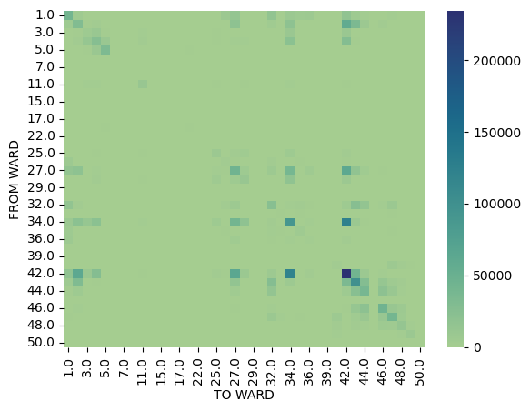

```python
# Heatmap general 2016
sns.heatmap(matrix_2016,cmap='crest')
```

It shows that in general in 2016, most of the trips happened in ward 42. After that there are wards 34 and 43 and also the trips among these three wards.

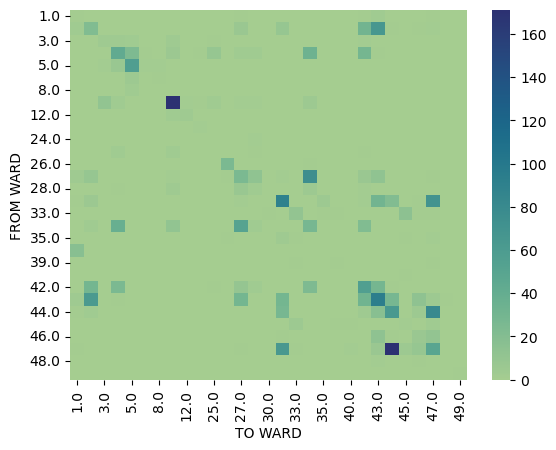

```python
# Heatmap 0-18 in 2016
sns.heatmap(matrix_age_under_18_2016,cmap='crest')
```

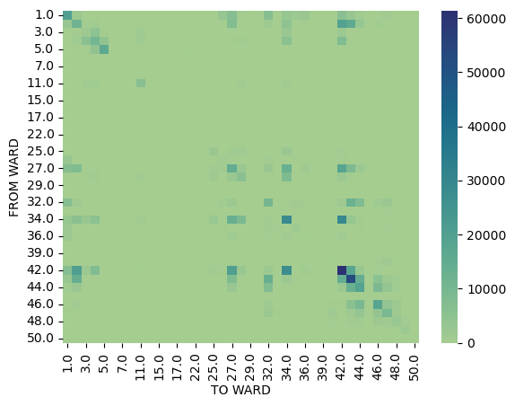

```python
# Heatmap 19-30 in 2016
sns.heatmap(matrix_age_19_30_2016,cmap='crest')
```

It shows that most of the young people's trips (19-30) in 2016 happened in wards 42 and 43.

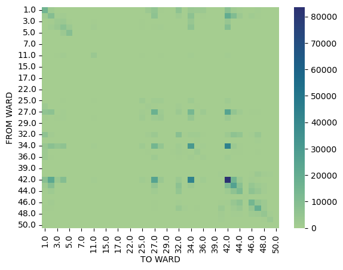

```python
# Heatmap 31-40 in 2016
sns.heatmap(matrix_age_31_40_2016,cmap='crest')
```

It shows that most of 31-40 people's trips in 2016 happened in ward 42. After that there are wards 43, 34 and 27 and also the trips among these wards.

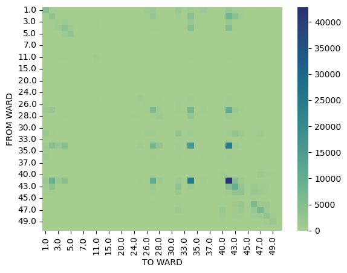

```python
# Heatmap 41-50 in 2016
sns.heatmap(matrix_age_41_50_2016,cmap='crest')
```

Almost the same pattern exists for 41-50 travelers.

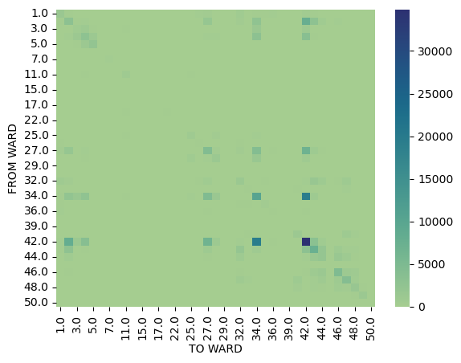

```python
# Heatmap 51-60 in 2016
sns.heatmap(matrix_age_51_60_2016,cmap='crest')
```

Almost the same pattern exists for 51-60 travelers.

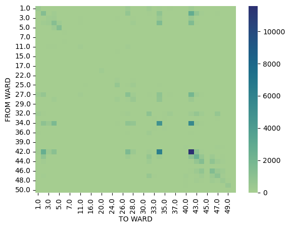

```python
# Heatmap above 61 in 2016
sns.heatmap(matrix_age_above_61_2016,cmap='crest')
```

Almost the same pattern exists for above 61 years old travelers.

...........................................................................................

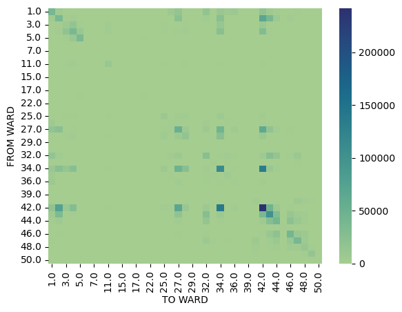

```python
# Heatmap general 2017
sns.heatmap(matrix_2017,cmap='crest')
```

In general, for whole 2017, the most trips happened inside ward 42 and after that from ward 42 to ward 34. insode ward 34 and from ward 34 to 42 are comming after them.

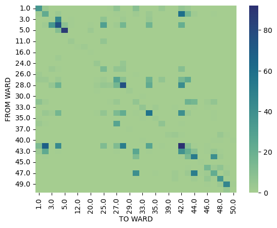

```python
# Heatmap 0-18 in 2017
sns.heatmap(matrix_age_under_18_2017,cmap='crest')
```

It shows that in 2017, teenagers' trips mostly happened inside the ward 5 and 42. also from ward 42 to 2.

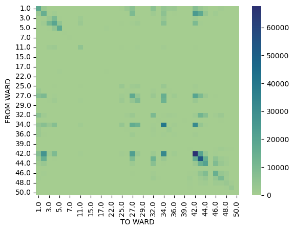

```python
# Heatmap 19-30 in 2017
sns.heatmap(matrix_age_19_30_2017,cmap='crest')
```

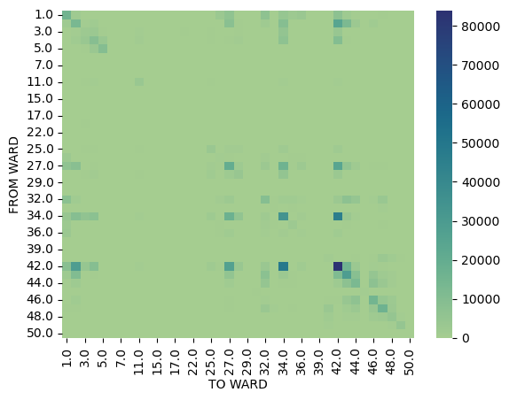

```python
# Heatmap 31-40 in 2017
sns.heatmap(matrix_age_31_40_2017,cmap='crest')
```

It shows that most of the 31-40 people trips in 2017 happened in ward 42. After that there are 43, 34 and also among these wards.

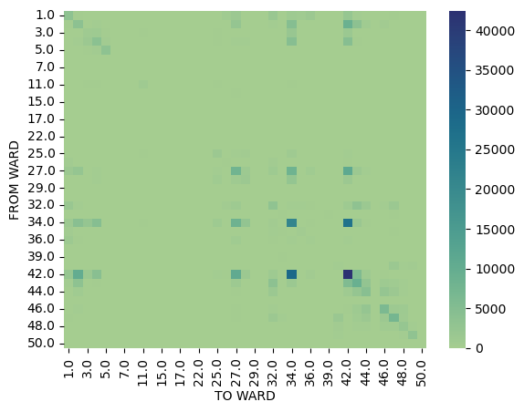

```python
# Heatmap 41-50 in 2017
sns.heatmap(matrix_age_41_50_2017,cmap='crest')
```

It shows that most of 42-50 people's trips in 2017 happened in wards 42 and 34 and among these two wards.

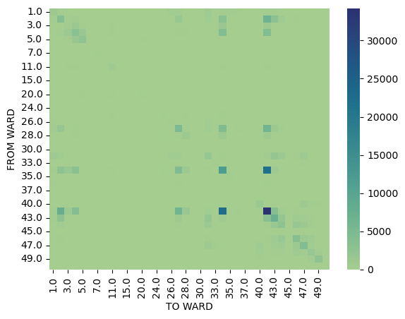

```python
# Heatmap 51-60 in 2017
sns.heatmap(matrix_age_51_60_2017,cmap='crest')
```

The same pattern exists for 51-60 people.

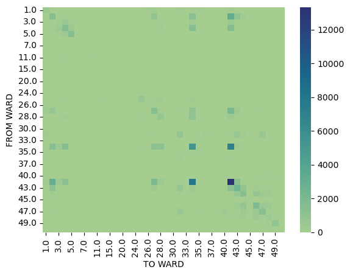

```python
# Heatmap above 61 in 2017
sns.heatmap(matrix_age_above_61_2017,cmap='crest')
```

The same pattern exists for old people (above 61).

...........................................................................................

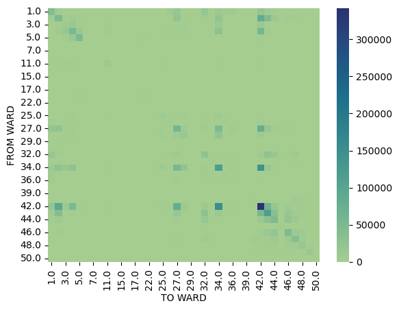

```python
# Heatmap general 2018
sns.heatmap(matrix_2018,cmap='crest')
```

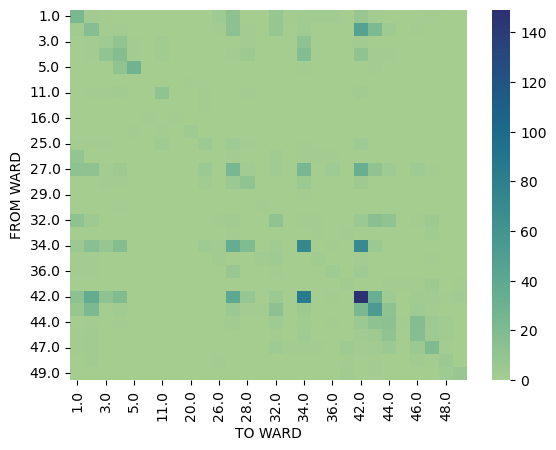

```python
# Heatmap 0-18 in 2018
sns.heatmap(matrix_age_under_18_2018,cmap='crest')
```

It shows that in 2018, the most of the teenagers' trips happened inside ward 42 and 34 and also between these two wards.

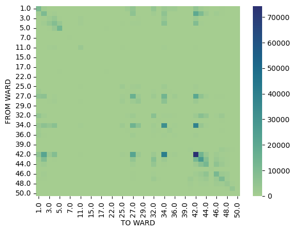

```python
# Heatmap 19-30 in 2018
sns.heatmap(matrix_age_19_30_2018,cmap='crest')
```

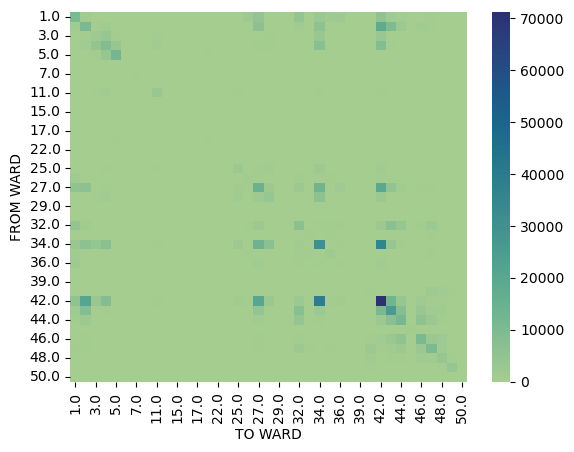

```python
# Heatmap 31-40 in 2018
sns.heatmap(matrix_age_31_40_2018,cmap='crest')
```

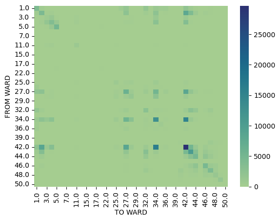

```python
# Heatmap 41-50 in 2018
sns.heatmap(matrix_age_41_50_2018,cmap='crest')
```

It shows that 41-50 people's trips in 2018 happened in ward 42 and after that inside the ward 34. Additionally, the trips among these two wards (both ways) are also high.

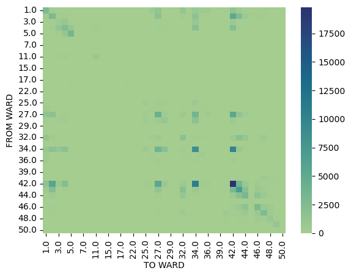

```python
# Heatmap 51-60 in 2018
sns.heatmap(matrix_age_51_60_2018,cmap='crest')
```

It shows that the same pattern exists for people between 51-60.

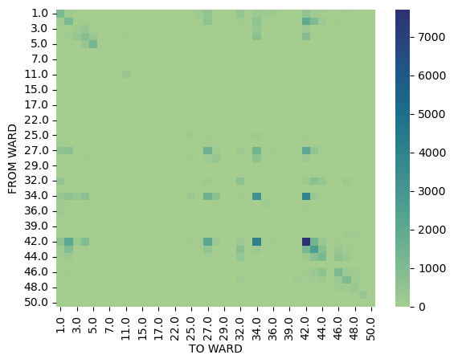

```python
# Heatmap above 61 in 2018
sns.heatmap(matrix_age_above_61_2018,cmap='crest')
```

It shows that, traveler above 61 years old, mostly travel inside ward 42 and after that from ward 42 to ward 34.

...........................................................................................

- Create a flowmap for the OD matrices.

[output not shown]

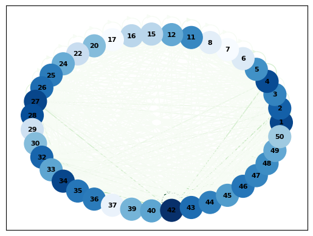

```python
import pandas as pd
import networkx as nx
import matplotlib.pyplot as plt
import seaborn as sns

matrix_2016.index = matrix_2016.index.astype(int)
matrix_2016.columns = matrix_2016.columns.astype(int)

# Create a directed graph from the OD matrix
G = nx.DiGraph()

# Add nodes
for node in matrix_2016.index:
    G.add_node(node)

# Add edges
for from_node in matrix_2016.index:
    for to_node in matrix_2016.columns:
        weight = matrix_2016.loc[from_node, to_node]
        if weight > 0:
            G.add_edge(from_node, to_node, weight=weight)

# Draw the graph with a circular layout
pos = nx.circular_layout(G)

# Set node colors based on degree (number of connections)
node_colors = [G.degree(node) for node in G.nodes]

# Set edge colors based on weights
edge_colors = [G[from_node][to_node]['weight'] for from_node, to_node in G.edges]

# Draw nodes
nx.draw_networkx_nodes(G, pos, node_size=700, node_color=node_colors, cmap=plt.cm.Blues)

# Draw edges with weights
nx.draw_networkx_edges(G, pos, width=1, edge_color=edge_colors, edge_cmap=plt.cm.Greens, arrowsize=10)

# Add labels
nx.draw_networkx_labels(G, pos, font_size=8, font_color='black', font_weight='bold')

# Add colorbar for edge weights
edge_weights = nx.get_edge_attributes(G, 'weight')
cbar = plt.colorbar()
cbar.set_label('Flow Counts')

plt.title("Flowmap for OD Matrix 2017")
plt.show()
```

[output not shown]

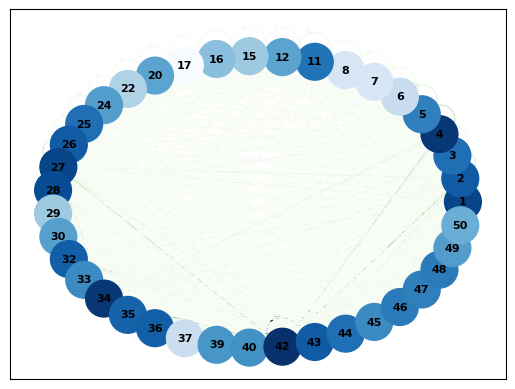

```python
import pandas as pd
import networkx as nx
import matplotlib.pyplot as plt
import seaborn as sns

matrix_2017.index = matrix_2017.index.astype(int)
matrix_2017.columns = matrix_2017.columns.astype(int)

# Create a directed graph from the OD matrix
G = nx.DiGraph()

# Add nodes
for node in matrix_2017.index:
    G.add_node(node)

# Add edges
for from_node in matrix_2017.index:
    for to_node in matrix_2017.columns:
        weight = matrix_2017.loc[from_node, to_node]
        if weight > 0:
            G.add_edge(from_node, to_node, weight=weight)

# Draw the graph with a circular layout
pos = nx.circular_layout(G)

# Set node colors based on degree (number of connections)
node_colors = [G.degree(node) for node in G.nodes]

# Set edge colors based on weights
edge_colors = [G[from_node][to_node]['weight'] for from_node, to_node in G.edges]

# Draw nodes
nx.draw_networkx_nodes(G, pos, node_size=700, node_color=node_colors, cmap=plt.cm.Blues)

# Draw edges with weights
nx.draw_networkx_edges(G, pos, width=1, edge_color=edge_colors, edge_cmap=plt.cm.Greens, arrowsize=10)

# Add labels
nx.draw_networkx_labels(G, pos, font_size=8, font_color='black', font_weight='bold')

# Add colorbar for edge weights
edge_weights = nx.get_edge_attributes(G, 'weight')
cbar = plt.colorbar()
cbar.set_label('Flow Counts')

plt.title("Flowmap for OD Matrix 2017")
plt.show()
```

[output not shown]

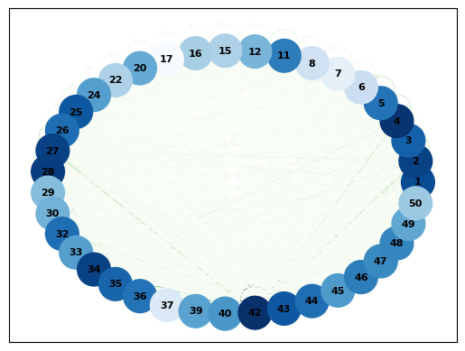

```python
import pandas as pd
import networkx as nx
import matplotlib.pyplot as plt
import seaborn as sns

matrix_2018.index = matrix_2018.index.astype(int)
matrix_2018.columns = matrix_2018.columns.astype(int)

# Create a directed graph from the OD matrix
G = nx.DiGraph()

# Add nodes
for node in matrix_2018.index:
    G.add_node(node)

# Add edges
for from_node in matrix_2018.index:
    for to_node in matrix_2018.columns:
        weight = matrix_2018.loc[from_node, to_node]
        if weight > 0:
            G.add_edge(from_node, to_node, weight=weight)

# Draw the graph with a circular layout
pos = nx.circular_layout(G)

# Set node colors based on degree (number of connections)
node_colors = [G.degree(node) for node in G.nodes]

# Set edge colors based on weights
edge_colors = [G[from_node][to_node]['weight'] for from_node, to_node in G.edges]

# Draw nodes
nx.draw_networkx_nodes(G, pos, node_size=700, node_color=node_colors, cmap=plt.cm.Blues)

# Draw edges with weights
nx.draw_networkx_edges(G, pos, width=1, edge_color=edge_colors, edge_cmap=plt.cm.Greens, arrowsize=10)

# Add labels
nx.draw_networkx_labels(G, pos, font_size=8, font_color='black', font_weight='bold')

# Add colorbar for edge weights
edge_weights = nx.get_edge_attributes(G, 'weight')
cbar = plt.colorbar()
cbar.set_label('Flow Counts')

plt.title("Flowmap for OD Matrix 2017")
plt.show()
```

# 3 - Relation to Public transport line

In this sectoin, I am going to do again some pre-processing on micro-mobility data (Divvy) and extract the csv files with coordinations. Also, I have downloaded the kml files of public transport in Chicago (such as bus stops, bus routes, subway rails, etc.). Thus, I will import the output of this section and those kml files into QGIS software to create some maps for further analysis.

```python
# Group data by wards in order to be used into QGIS for further analysis.
```

```python
import pandas as pd
```

```python
df_MM_clean_2016 = pd.read_csv('df_MM_clean_2016', on_bad_lines = 'warn', sep=',')
df_MM_clean_2017 = pd.read_csv('df_MM_clean_2017', on_bad_lines = 'warn', sep=',')
df_MM_clean_2018 = pd.read_csv('df_MM_clean_2018', on_bad_lines = 'warn', sep=',')
```

```python
number_of_start_trips = df_MM_clean_2016.groupby("FROM WARD").size().reset_index(name='number_of_start_trips_2016')
```

```python
number_of_start_trips.to_csv("number_of_start_trips_2016", index=False)
```

```python
number_of_start_trips_2017 = df_MM_clean_2017.groupby("FROM WARD").size().reset_index(name='number_of_start_trips_2017')
```

```python
number_of_start_trips_2017.to_csv("number_of_start_trips_2017", index=False)
```

```python
number_of_start_trips_2018 = df_MM_clean_2018.groupby("FROM WARD").size().reset_index(name='number_of_start_trips_2018')
```

```python
number_of_start_trips_2018.to_csv("number_of_start_trips_2018", index=False)
```

```python
number_of_end_trips_2016 = df_MM_clean_2016.groupby("TO WARD").size().reset_index(name='number_of_end_trips_2016')
```

```python
number_of_end_trips_2016.to_csv("number_of_end_trips_2016", index=False)
```

```python
number_of_end_trips_2017 = df_MM_clean_2017.groupby("TO WARD").size().reset_index(name='number_of_end_trips_2017')
```

```python
number_of_end_trips_2017.to_csv("number_of_end_trips_2017", index=False)
```

```python
number_of_end_trips_2018 = df_MM_clean_2018.groupby("TO WARD").size().reset_index(name='number_of_end_trips_2018')
```

```python
number_of_end_trips_2018.to_csv("number_of_end_trips_2018", index=False)
```

```python
df_MM_clean_2019 = pd.read_csv('df_2019.csv', on_bad_lines = 'warn', sep=',')
```

```python
number_of_start_trips_2019 = df_MM_clean_2019.groupby("FROM WARD").size().reset_index(name='number_of_start_trips_2019')
```

```python
number_of_start_trips_2019.to_csv("number_of_start_trips_2019", index=False)
```

```python
number_of_end_trips_2019 = df_MM_clean_2019.groupby("TO WARD").size().reset_index(name='number_of_start_trips_2019')
```

```python
number_of_end_trips_2019.to_csv("number_of_end_trips_2019", index=False)
```

Here, I am dividing a day into 3 day times (Day, Evening and Night) to do some analysis based on the time of trips in QGIS software.

```python
# day time
df_MM_clean_2016_time = pd.to_datetime(df_MM_clean_2016['START TIME'], format="%m/%d/%Y %I:%M:%S %p")
df_MM_clean_2017_time = pd.to_datetime(df_MM_clean_2017['START TIME'], format="%m/%d/%Y %I:%M:%S %p")
df_MM_clean_2018_time = pd.to_datetime(df_MM_clean_2018['START TIME'], format="%m/%d/%Y %I:%M:%S %p")
```

```python
import datetime as dt
df_MM_clean_2016["HOUR"] = df_MM_clean_2016_time.dt.strftime("%H")
df_MM_clean_2017["HOUR"] = df_MM_clean_2017_time.dt.strftime("%H")
df_MM_clean_2018["HOUR"] = df_MM_clean_2018_time.dt.strftime("%H")
```

```python
# Function for day time
def day_time(hour):
    if  hour=='00' or hour=='01' or hour=='02' or hour=='03' or hour=='04' or hour=='05' or hour=='06' or hour=='07':
        return 'Night'
    elif hour=='08' or hour=='09' or hour=='10' or hour=='11' or hour=='12' or hour=='13' or hour=='14' or hour=='15':
        return 'Day'
    elif hour=='16' or hour=='17' or hour=='18' or hour=='19' or hour=='20' or hour=='21' or hour=='22' or hour=='23':
        return 'Evening'
```

```python
df_MM_clean_2016["DAY_TIME"] = df_MM_clean_2016["HOUR"].apply(day_time)
df_MM_clean_2017["DAY_TIME"] = df_MM_clean_2017["HOUR"].apply(day_time)
df_MM_clean_2018["DAY_TIME"] = df_MM_clean_2018["HOUR"].apply(day_time)
```

```python
df_MM_clean_2016.head()
```

|  | TRIP ID | START TIME | STOP TIME | BIKE ID | TRIP DURATION | FROM STATION ID | FROM STATION NAME | TO STATION ID | TO STATION NAME | USER TYPE | ... | SEASON | DAY OF WEEK | from_point | to_point | FROM WARD | TO WARD | age | age group | HOUR | DAY_TIME |
| --- | --- | --- | --- | --- | --- | --- | --- | --- | --- | --- | --- | --- | --- | --- | --- | --- | --- | --- | --- | --- | --- |
| 0 | 10000000 | 06/09/2016 06:24:00 PM | 06/09/2016 06:33:00 PM | 5 | 516 | 26 | McClurg Ct & Illinois St | 90 | Millennium Park | Subscriber | ... | Summer | Thursday | POINT (-87.6173 41.89102) | POINT (-87.624084 41.881032) | 42.0 | 42.0 | 28 | 19-30 | 18 | Evening |
| 1 | 10000001 | 06/09/2016 06:24:00 PM | 06/09/2016 06:27:00 PM | 4201 | 163 | 238 | Ravenswood Ave & Montrose Ave (*) | 234 | Clark St & Montrose Ave | Subscriber | ... | Summer | Thursday | POINT (-87.674365 41.961615) | POINT (-87.666036 41.961588) | 47.0 | 47.0 | 32 | 31-40 | 18 | Evening |
| 2 | 10000002 | 06/09/2016 06:25:00 PM | 06/09/2016 06:41:00 PM | 1976 | 987 | 91 | Clinton St & Washington Blvd | 289 | Wells St & Concord Ln | Subscriber | ... | Summer | Thursday | POINT (-87.64117 41.88338) | POINT (-87.634656 41.912133) | 42.0 | 2.0 | 27 | 19-30 | 18 | Evening |
| 3 | 10000003 | 06/09/2016 06:25:00 PM | 06/09/2016 06:33:00 PM | 5354 | 518 | 310 | Damen Ave & Charleston St | 327 | Sheffield Ave & Webster Ave | Subscriber | ... | Summer | Thursday | POINT (-87.677855 41.920082) | POINT (-87.653818 41.92154) | 32.0 | 43.0 | 29 | 19-30 | 18 | Evening |
| 4 | 10000005 | 06/09/2016 06:25:00 PM | 06/09/2016 06:38:00 PM | 4365 | 813 | 20 | Sheffield Ave & Kingsbury St | 153 | Southport Ave & Wellington Ave | Subscriber | ... | Summer | Thursday | POINT (-87.653106 41.910522) | POINT (-87.663576 41.935733) | 27.0 | 32.0 | 35 | 31-40 | 18 | Evening |

5 rows × 30 columns

```python
group_day_time_2016 = df_MM_clean_2016.groupby(["FROM WARD", "DAY_TIME"]).size().reset_index(name='group_day_time_2016')
```

```python
group_day_time_2017 = df_MM_clean_2017.groupby(["FROM WARD", "DAY_TIME"]).size().reset_index(name='group_day_time_2017')
```

```python
group_day_time_2018 = df_MM_clean_2018.groupby(["FROM WARD", "DAY_TIME"]).size().reset_index(name='group_day_time_2018')
```

```python
group_day_time_2016.to_csv("group_day_time_2016", index=False)
```

```python
group_day_time_2017.to_csv("group_day_time_2017", index=False)
```

```python
group_day_time_2018.to_csv("group_day_time_2018", index=False)
```

# 4 – Utilization of bicycles and costs

In this section, I am going to calculate the utilization percentage of bicycles and also assess the cost and benefit of the bike-sharing company. For this purpose, I have made a rough estimation of bicycle maintenance costs and the revenue from each bike based on the trip duration. This is just a simple simulation of this kind of analysis.

```python
# Working on the last year of data 2019
```

```python
import pandas as pd
df_MM_clean_2019 = pd.read_csv('dataframe_2019 (1).csv', on_bad_lines = 'warn', sep=',')
```

```python
# Create datetime from "START TIME", "STOP TIME"
df_MM_clean_2019['START TIME'] = pd.to_datetime(df_MM_clean_2019['START TIME'])
df_MM_clean_2019['STOP TIME'] = pd.to_datetime(df_MM_clean_2019['STOP TIME'])
```

```python
# Geoup by "BIKE ID"
group_bikes = df_MM_clean_2019.groupby("BIKE ID").agg({"TRIP DURATION": "sum",
                                                      "START TIME": "min",
                                                      "STOP TIME": "max"})
```

```python
# Convert from seconds to minutes
group_bikes["TRIP DURATION (MINUTES)"] = group_bikes["TRIP DURATION"]/60
```

```python
# Classic bike price of divvy = 0.17$/min
```

```python
# Calculate the revenue
group_bikes["REVENUE (USD)"] = group_bikes["TRIP DURATION (MINUTES)"] * 0.17
```

```python
# Calculate the total time that each bicycle exists on the streets
group_bikes["ACTIVE TIME"] = (group_bikes["STOP TIME"] - group_bikes["START TIME"]).dt.total_seconds() / 60
```

```python
# Calculate the utilization percentage of each bike
group_bikes["utilization_percentage"] = ((group_bikes["TRIP DURATION (MINUTES)"] / group_bikes["ACTIVE TIME"]) * 100)
```

```python
group_bikes.head()
```

| BIKE ID | TRIP DURATION | START TIME | STOP TIME | TRIP DURATION (MINUTES) | REVENUE (USD) | ACTIVE TIME | utilization_percentage |
| --- | --- | --- | --- | --- | --- | --- | --- |
| 1 | 674786 | 2019-01-14 07:54:08 | 2019-12-28 22:32:06 | 11246.433333 | 1911.893667 | 501997.966667 | 2.240334 |
| 2 | 6618706 | 2019-02-25 00:59:06 | 2019-12-31 07:36:02 | 110311.766667 | 18753.000333 | 445356.933333 | 24.769294 |
| 3 | 834957 | 2019-02-22 07:04:14 | 2019-11-09 21:42:37 | 13915.950000 | 2365.711500 | 375278.383333 | 3.708167 |
| 4 | 939373 | 2019-04-11 17:25:27 | 2019-12-29 16:14:28 | 15656.216667 | 2661.556833 | 377209.016667 | 4.150541 |
| 5 | 391873 | 2019-01-08 13:13:01 | 2019-12-30 14:47:56 | 6531.216667 | 1110.306833 | 512734.916667 | 1.273800 |

```python
group_bikes["utilization_percentage"].mean()
```

```
3.843668012819399
```

The average of utilization percentage of bikes is about 3.8%.

```python
group_bikes["utilization_percentage"].median()
```

```
3.055378640027452
```

```python
group_bikes["utilization_percentage"].max()
```

```
100.0
```

```python
group_bikes["utilization_percentage"].min()
```

```
0.0031177561471445667
```

```python
group_bikes.sort_values("REVENUE (USD)", ascending = False).head()
```

| BIKE ID | TRIP DURATION | START TIME | STOP TIME | TRIP DURATION (MINUTES) | REVENUE (USD) | ACTIVE TIME | utilization_percentage |
| --- | --- | --- | --- | --- | --- | --- | --- |
| 3846 | 11124484 | 2019-01-14 08:01:04 | 2019-10-09 14:29:43 | 185408.066667 | 31519.371333 | 386308.650000 | 47.994801 |
| 1229 | 9550031 | 2019-01-02 09:57:50 | 2019-12-29 19:20:44 | 159167.183333 | 27058.421167 | 520402.900000 | 30.585376 |
| 6232 | 9287412 | 2019-03-06 11:50:03 | 2020-01-13 21:55:24 | 154790.200000 | 26314.334000 | 451325.350000 | 34.296810 |
| 1083 | 9098417 | 2019-01-01 12:47:38 | 2020-01-21 13:54:35 | 151640.283333 | 25778.848167 | 554466.950000 | 27.348841 |
| 773 | 8538863 | 2019-01-05 18:27:43 | 2019-10-25 10:56:54 | 142314.383333 | 24193.445167 | 421469.183333 | 33.766261 |

We can see that Bike 3846 with 48% utilization percentage, made about 31,519 dolar with 185,408 minutes trip.

```python
total_revenue = group_bikes["REVENUE (USD)"].sum()
```

```python
print(f'the total revenue is {total_revenue}')
```

```
the total revenue is 15687834.081500001
```

The revenue that we hav calculated, shows that in 2019, divvy made at least 15.68 M$.

```python
# Costs for classic bikes per ye
bikes_price = 300
maintenance = 50
infrastructure = 800
technology = 30
insurance = 10
operations = 60
marketing = 20
unexpected_costs = 20
```

```python
# Calculate the total cost for divvy per each bike
cost = bikes_price + maintenance + infrastructure + technology + insurance + operations + marketing + unexpected_costs
```

```python
print(f'the cost for each bike in 2019 is {cost}')
```

```
the cost for each bike in 2019 is 1290
```

```python
group_bikes.count()
```

```
TRIP DURATION              6017
START TIME                 6017
STOP TIME                  6017
TRIP DURATION (MINUTES)    6017
REVENUE (USD)              6017
ACTIVE TIME                6017
utilization_percentage     6017
dtype: int64
```

```python
total_cost = 6017 * cost
```

```python
print(f'the total cost in 2019 is {total_cost}')
```

```
the total cost in 2019 is 7761930
```

```python
interest = total_revenue - total_cost
```

```python
print(f'the interest in 2019 is {interest}')
```

```
the interest in 2019 is 7925904.081500001
```

I have estimated that there was about 8 M$ benefit for Divvy in 2019.

...........................................................................................

```python
# During different day of week
```

```python
group_bikes_week = df_MM_clean_2019.groupby(["BIKE ID", "Day_of_Week"]).agg({"TRIP DURATION": "sum",
                                                                          "START TIME": "min",
                                                                          "STOP TIME": "max"})
```

```python
# Convert from seconds to minutes
group_bikes_week["TRIP DURATION (MINUTES)"] = group_bikes_week["TRIP DURATION"]/60
```

```python
# Calculate the total time that each bicycle exists on the streets in each day of week
group_bikes_week["ACTIVE TIME"] = (group_bikes_week["STOP TIME"] - group_bikes_week["START TIME"]).dt.total_seconds() / 60
```

```python
# Calculate the utilization percentage of each bike in each day of week
group_bikes_week["utilization_percentage"] = ((group_bikes_week["TRIP DURATION (MINUTES)"] / group_bikes_week["ACTIVE TIME"]) * 100)
```

```python
group_bikes_week.head(14)
```

| BIKE ID | Day_of_Week | TRIP DURATION | START TIME | STOP TIME | TRIP DURATION (MINUTES) | ACTIVE TIME | utilization_percentage |
| --- | --- | --- | --- | --- | --- | --- | --- |
| 1 | Friday | 131254 | 2019-02-22 14:34:53 | 2019-12-27 06:02:59 | 2187.566667 | 443008.100000 | 0.493798 |
|  | Monday | 89813 | 2019-01-14 07:54:08 | 2019-09-09 18:53:30 | 1496.883333 | 343379.366667 | 0.435927 |
|  | Saturday | 131591 | 2019-03-16 17:03:42 | 2019-12-28 22:32:06 | 2193.183333 | 413608.400000 | 0.530256 |
|  | Sunday | 83157 | 2019-03-10 19:59:49 | 2019-09-08 12:07:21 | 1385.950000 | 261607.533333 | 0.529782 |
|  | Thursday | 64400 | 2019-01-17 16:40:10 | 2019-09-12 18:36:49 | 1073.333333 | 342836.650000 | 0.313074 |
|  | Tuesday | 105962 | 2019-02-26 09:06:35 | 2019-10-15 23:47:58 | 1766.033333 | 333521.383333 | 0.529511 |
|  | Wednesday | 68609 | 2019-02-27 17:55:27 | 2019-10-09 18:52:46 | 1143.483333 | 322617.316667 | 0.354440 |
| 2 | Friday | 43249 | 2019-03-15 11:36:32 | 2019-12-06 09:07:14 | 720.816667 | 382890.700000 | 0.188257 |
|  | Monday | 55960 | 2019-02-25 00:59:06 | 2019-12-30 18:30:04 | 932.666667 | 444570.966667 | 0.209790 |
|  | Saturday | 107622 | 2019-03-02 16:02:50 | 2019-12-07 12:11:52 | 1793.700000 | 402969.033333 | 0.445121 |
|  | Sunday | 97991 | 2019-03-03 14:14:48 | 2019-12-29 13:54:59 | 1633.183333 | 433420.183333 | 0.376813 |
|  | Thursday | 37374 | 2019-03-07 17:30:22 | 2019-12-12 11:27:22 | 622.900000 | 402837.000000 | 0.154628 |
|  | Tuesday | 296018 | 2019-03-05 04:51:18 | 2019-12-31 07:36:02 | 4933.633333 | 433604.733333 | 1.137818 |
|  | Wednesday | 5980492 | 2019-02-27 21:10:52 | 2019-12-04 17:31:56 | 99674.866667 | 402981.066667 | 24.734380 |

```python
group_bikes_week.sort_values('utilization_percentage', ascending=False).head()
```

| BIKE ID | Day_of_Week | TRIP DURATION | START TIME | STOP TIME | TRIP DURATION (MINUTES) | ACTIVE TIME | utilization_percentage |
| --- | --- | --- | --- | --- | --- | --- | --- |
| 56 | Wednesday | 439 | 2019-05-01 14:16:17 | 2019-05-01 14:23:36 | 7.316667 | 7.316667 | 100.0 |
| 3973 | Monday | 578 | 2019-03-18 18:28:14 | 2019-03-18 18:37:52 | 9.633333 | 9.633333 | 100.0 |
| 6206 | Monday | 150 | 2019-06-17 13:54:49 | 2019-06-17 13:57:19 | 2.500000 | 2.500000 | 100.0 |
| 2581 | Monday | 212030 | 2019-07-15 09:03:03 | 2019-07-17 19:56:53 | 3533.833333 | 3533.833333 | 100.0 |
| 3973 | Thursday | 27338 | 2019-04-11 19:09:46 | 2019-04-12 02:45:24 | 455.633333 | 455.633333 | 100.0 |

```python
week_days = group_bikes_week.groupby("Day_of_Week").agg({"utilization_percentage": "mean"})
```

```python
week_days.head(7)
```

| Day_of_Week | utilization_percentage |
| --- | --- |
| Friday | 0.713160 |
| Monday | 0.662425 |
| Saturday | 1.043443 |
| Sunday | 0.803796 |
| Thursday | 0.739848 |
| Tuesday | 0.821461 |
| Wednesday | 0.724842 |

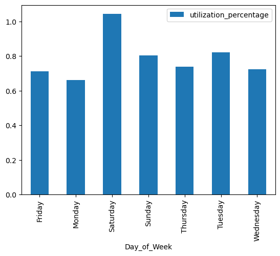

```python
# The bar plot of average of utilization percentage within each day of week:
bp_week_days = week_days.plot(kind = "bar")
```

```python
week_days_median = group_bikes_week.groupby("Day_of_Week").agg({"utilization_percentage": "median"})
```

```python
week_days_median.head(7)
```

| Day_of_Week | utilization_percentage |
| --- | --- |
| Friday | 0.429317 |
| Monday | 0.408524 |
| Saturday | 0.553881 |
| Sunday | 0.462633 |
| Thursday | 0.408802 |
| Tuesday | 0.397998 |
| Wednesday | 0.397965 |

```python
group_bikes.to_csv("group_bikes_2019_2", index=False)
```

```python
group_bikes_week.to_csv("group_bikes_week_2019_2", index=False)
```

This is the end of this Analysis. More analysis can be done in further efforts.